# Laboratorio 1 Análisis Exploratorio

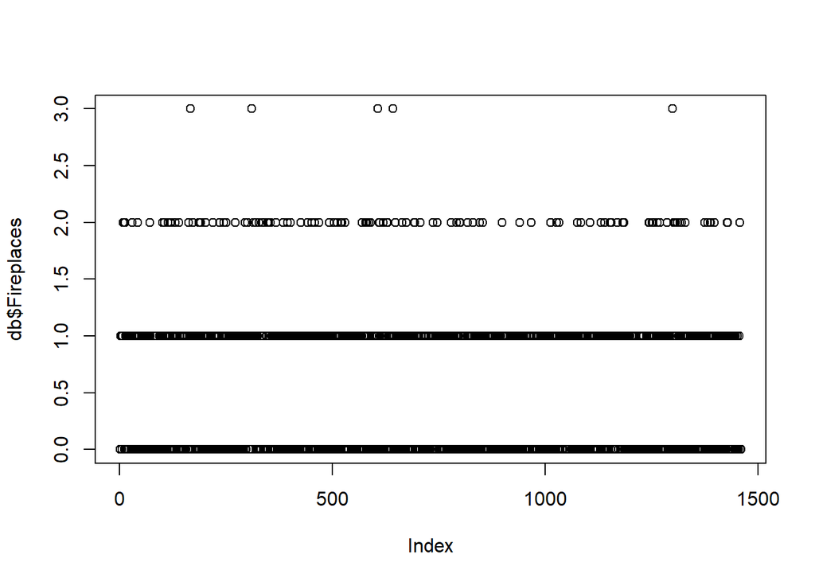

```r
plot(db$Fireplaces)
```

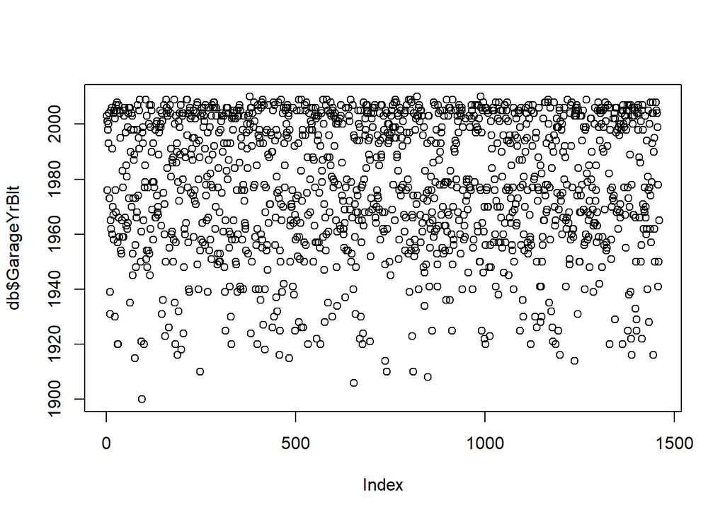

```r
plot(db$GarageYrBlt)
```

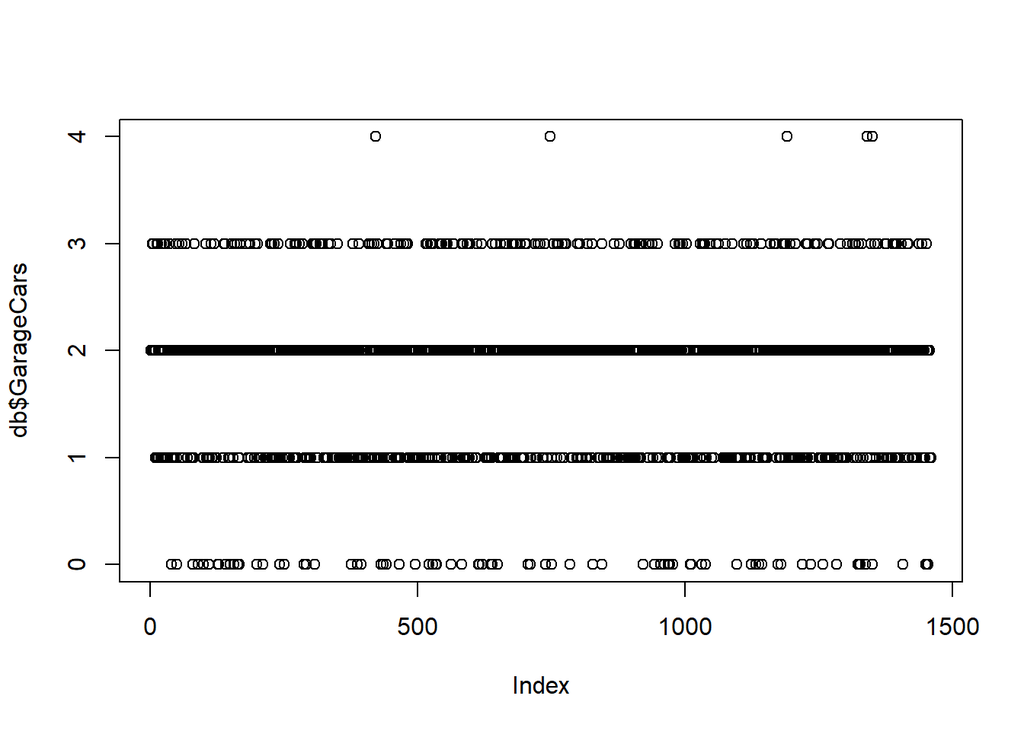

```r
plot(db$GarageCars)
```

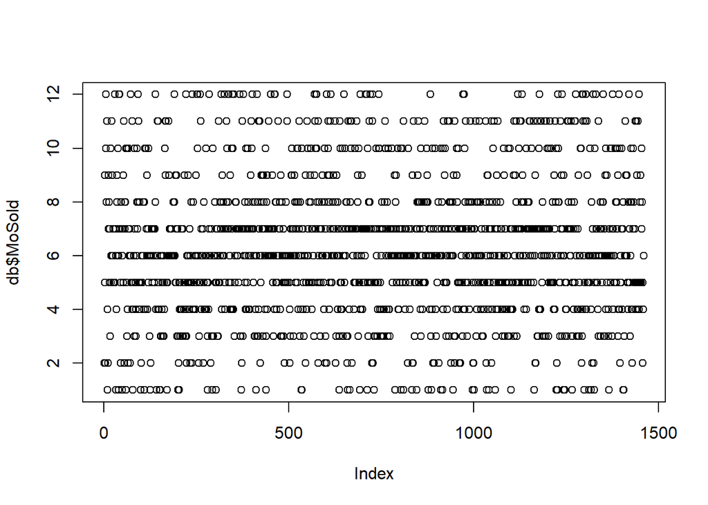

```r
plot(db$MoSold)
```

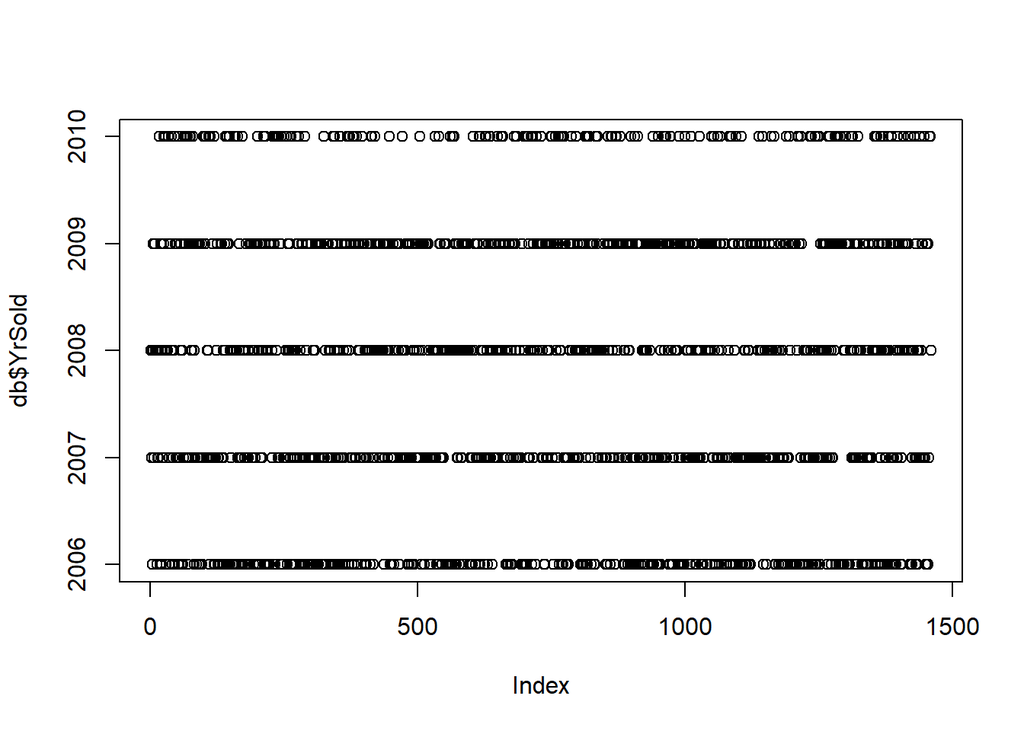

```r
plot(db$YrSold)
```

### Cualitativas

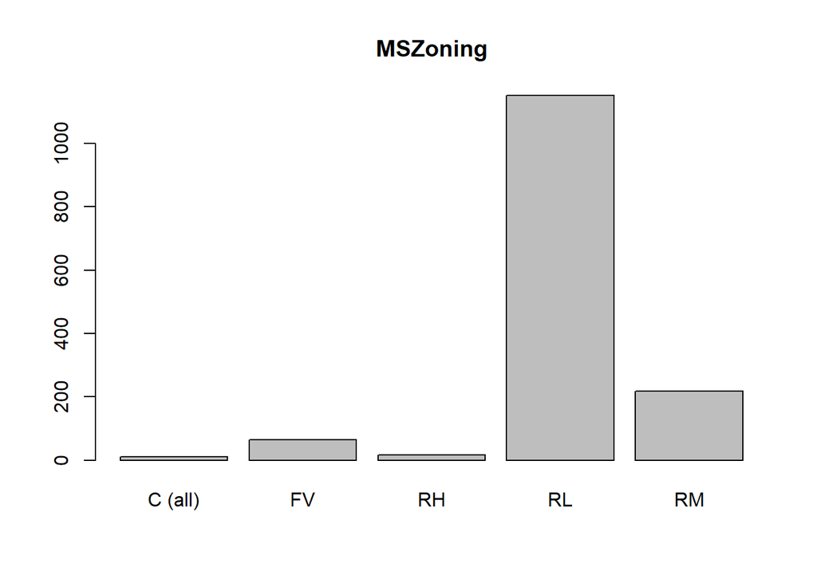

```r
barplot(t1,  main = "MSZoning")
```

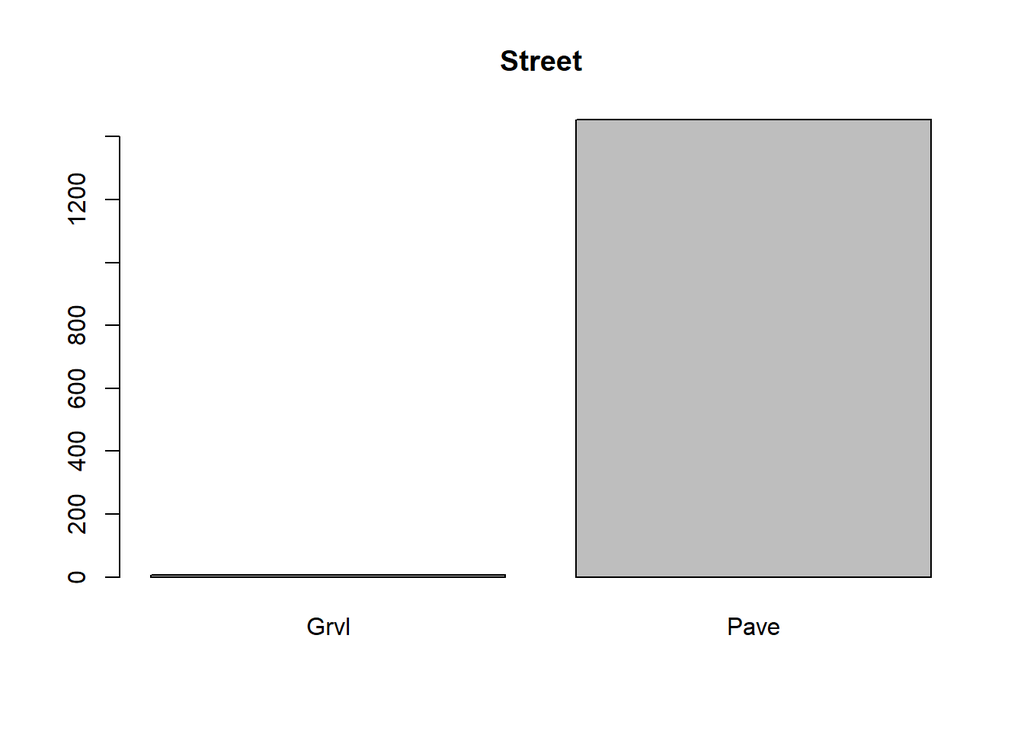

```r
barplot(t2,  main = "Street")
```

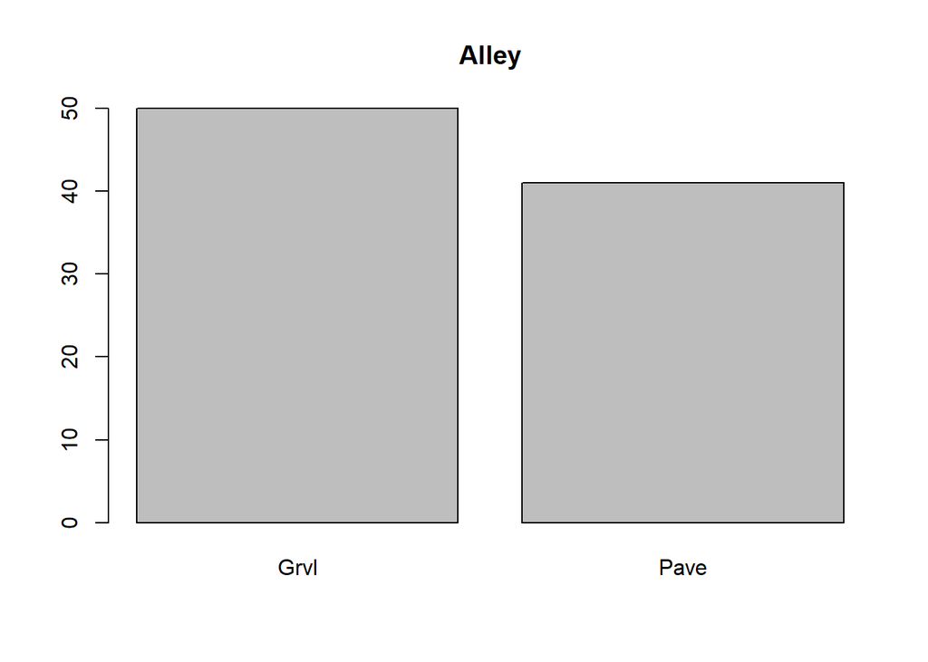

```r
barplot(t3,  main = "Alley")
```

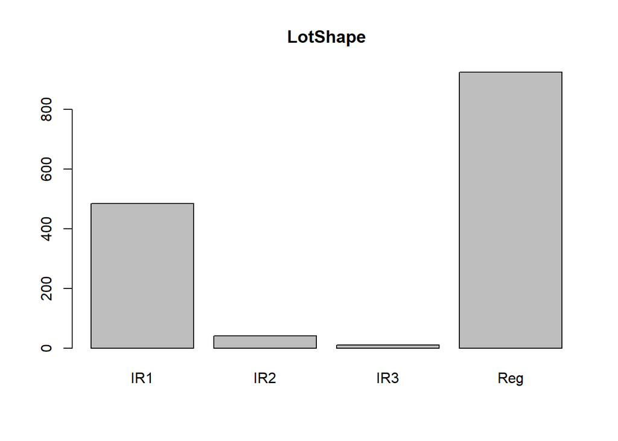

```r
barplot(t4,  main = "LotShape")
```

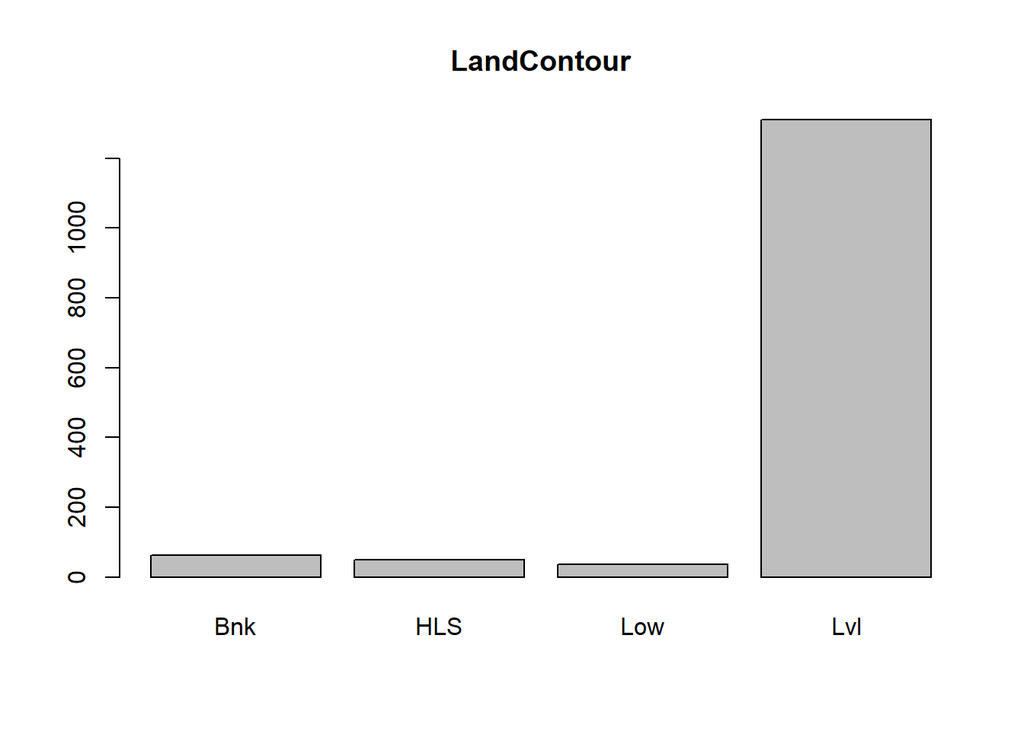

```r
barplot(t5,  main = "LandContour")
```

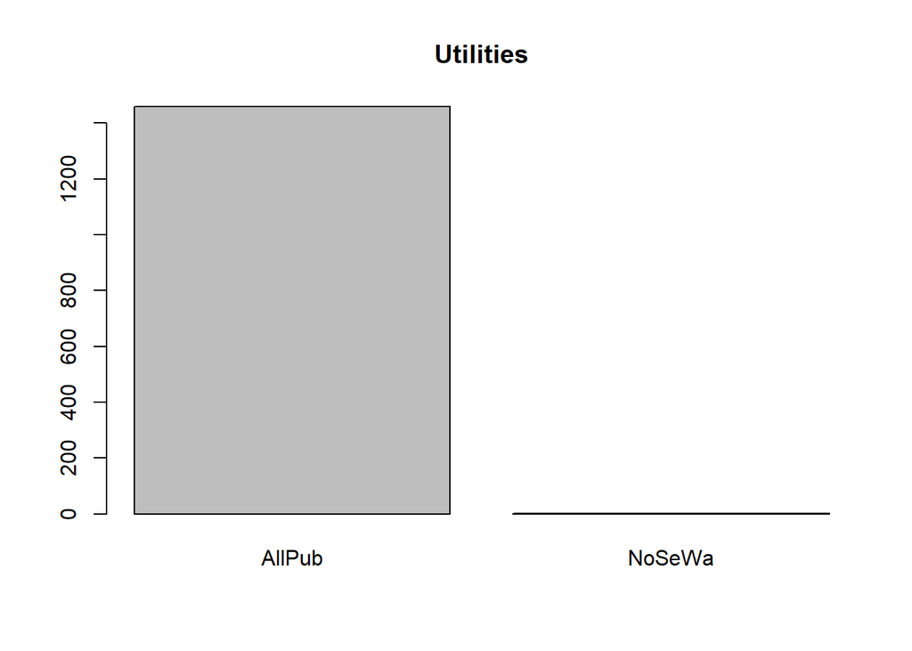

```r
barplot(t6,  main = "Utilities")
```

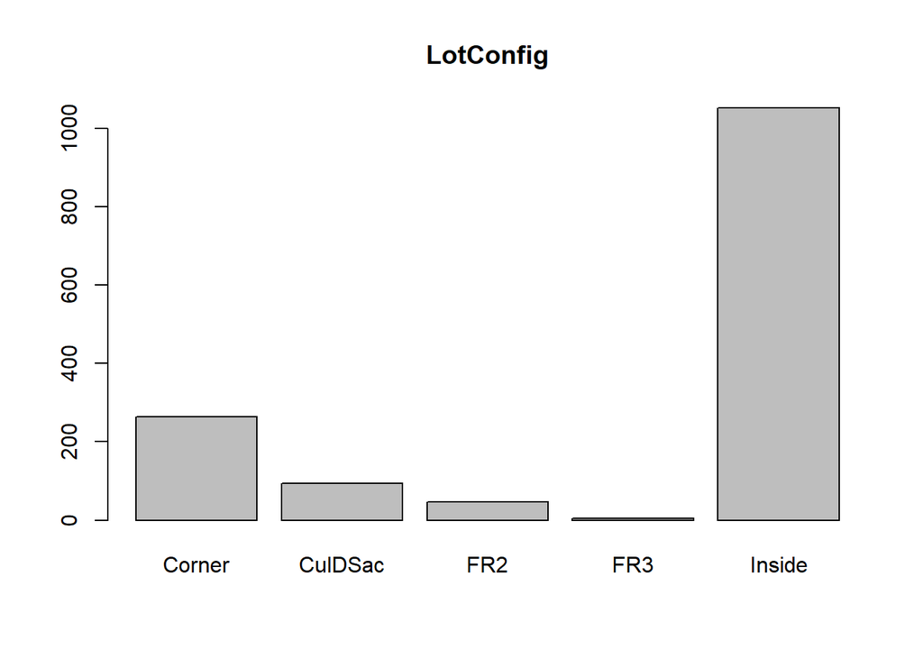

```r
barplot(t7,  main = "LotConfig")
```

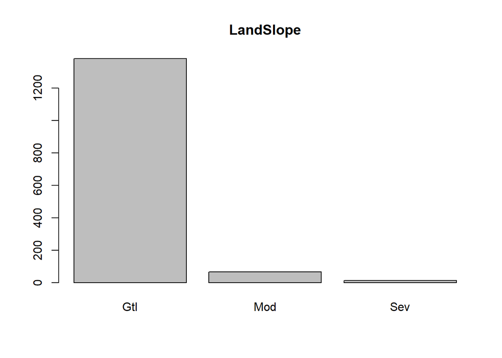

```r
barplot(t8,  main = "LandSlope")
```

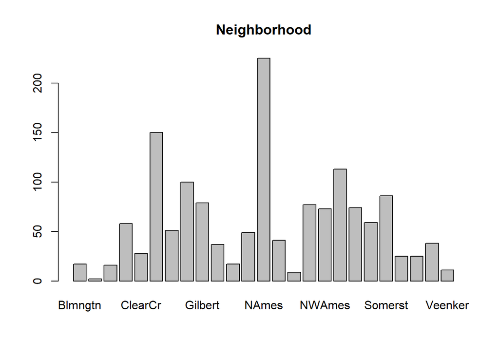

```r
barplot(t9,  main = "Neighborhood")
```

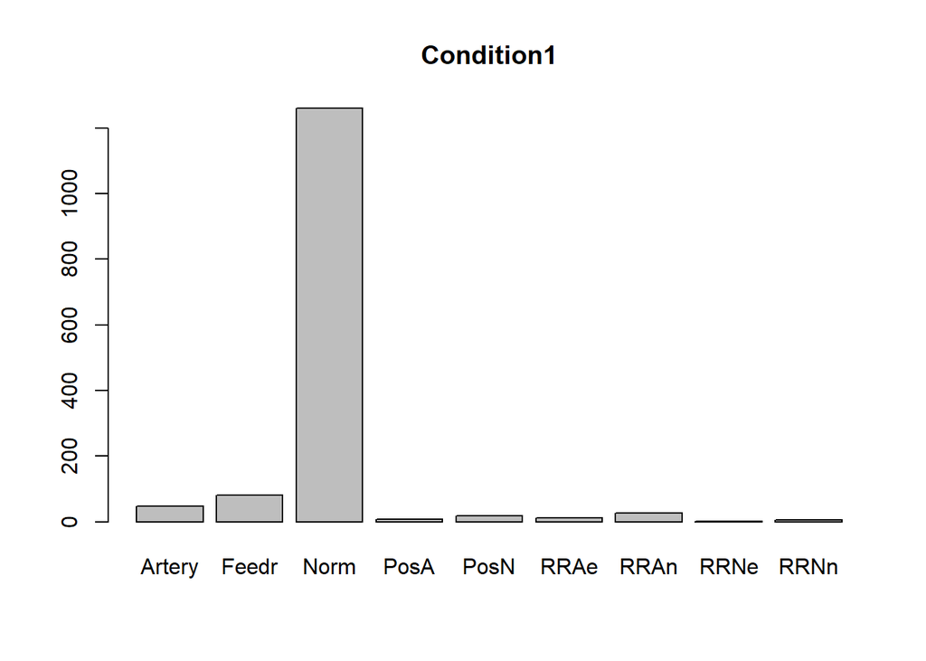

```r
barplot(t10,  main = "Condition1")
```

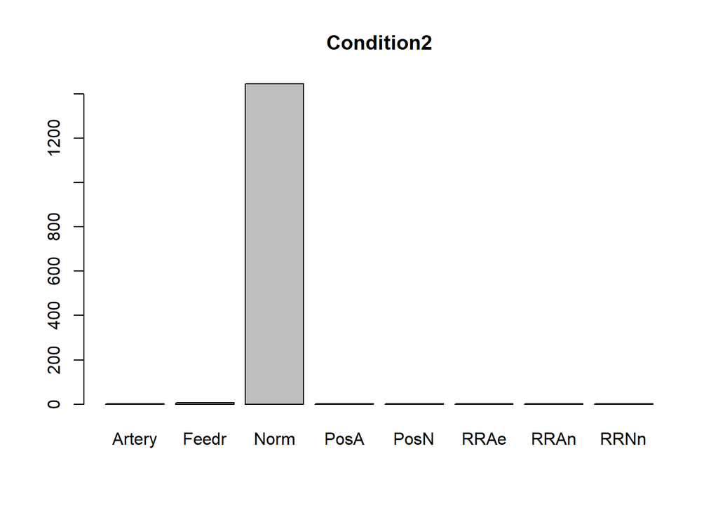

```r
barplot(t11,  main = "Condition2")
```

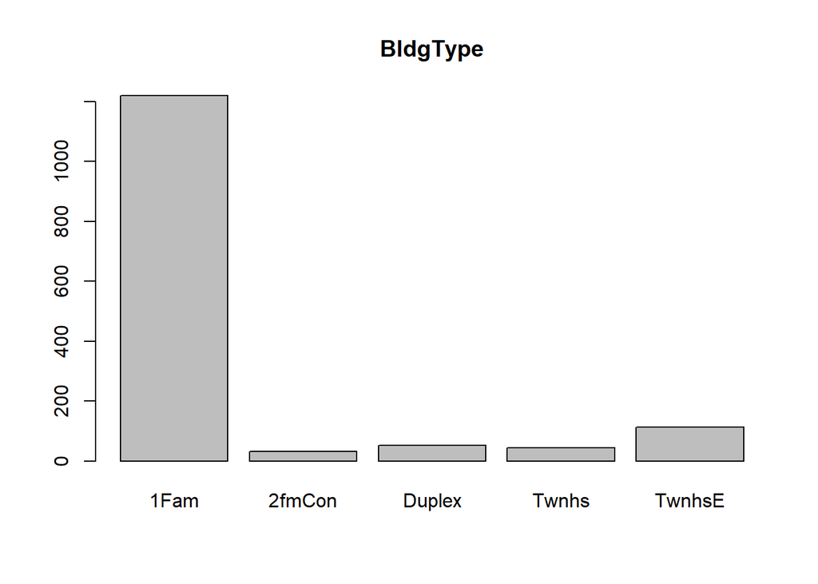

```r
barplot(t12,  main = "BldgType")
```

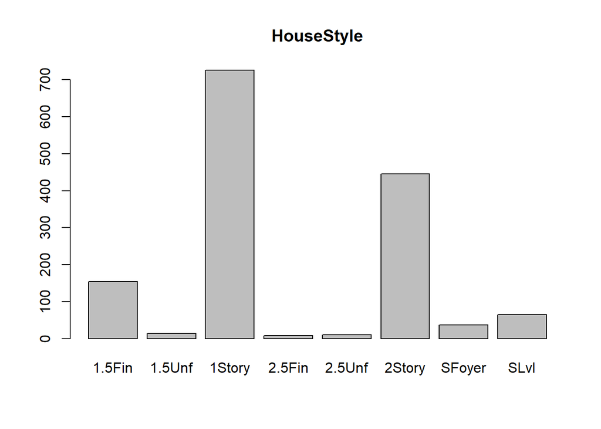

```r
barplot(t13,  main = "HouseStyle")
```

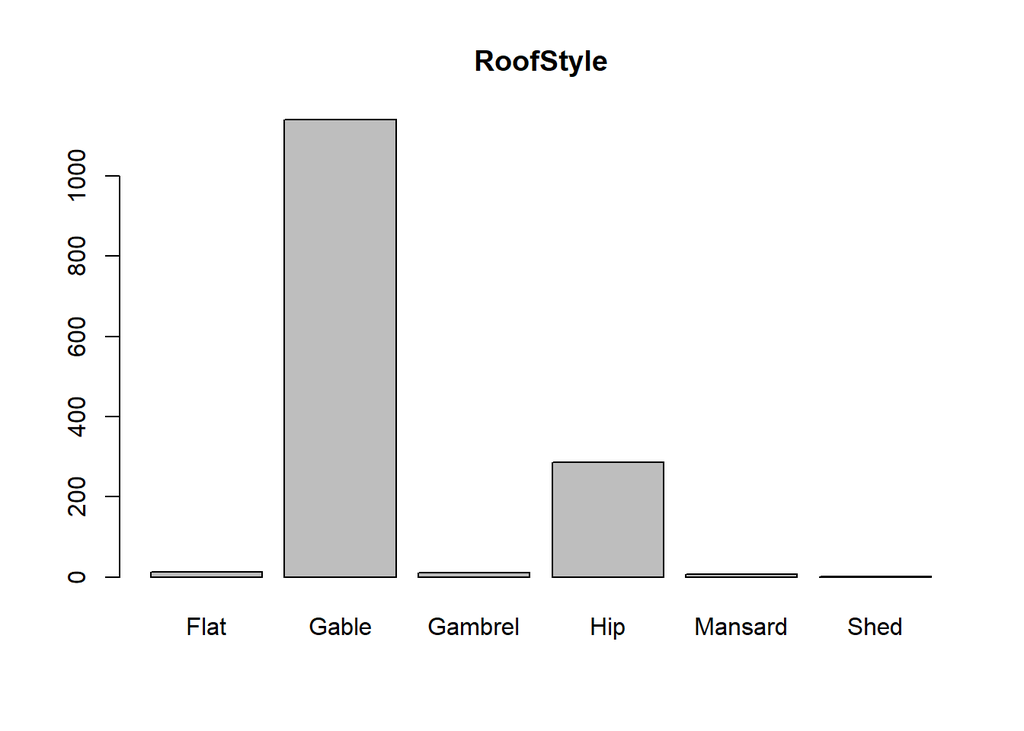

```r
barplot(t14,  main = "RoofStyle")
```

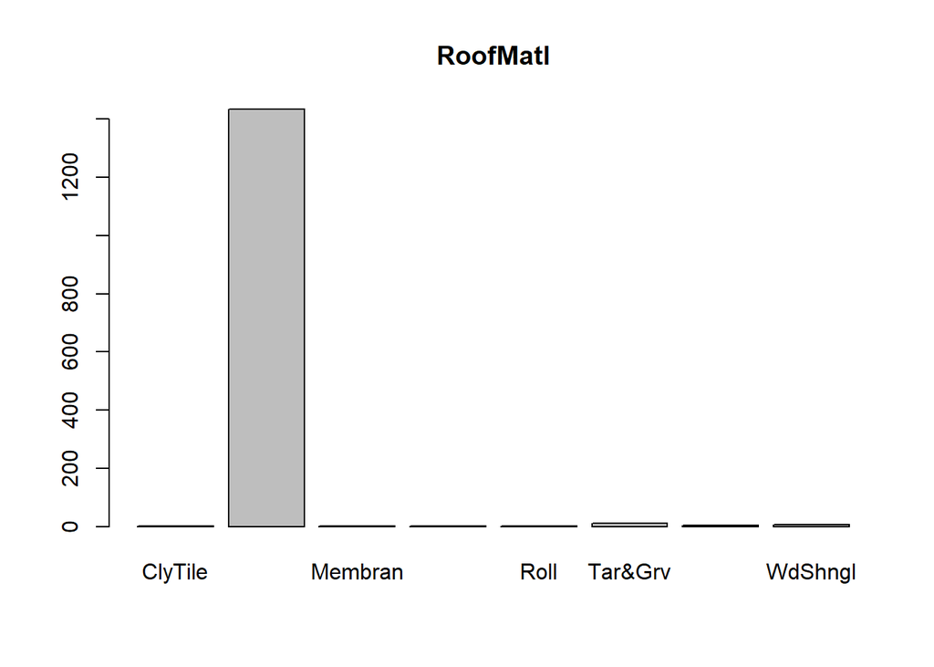

```r
barplot(t15,  main = "RoofMatl")
```

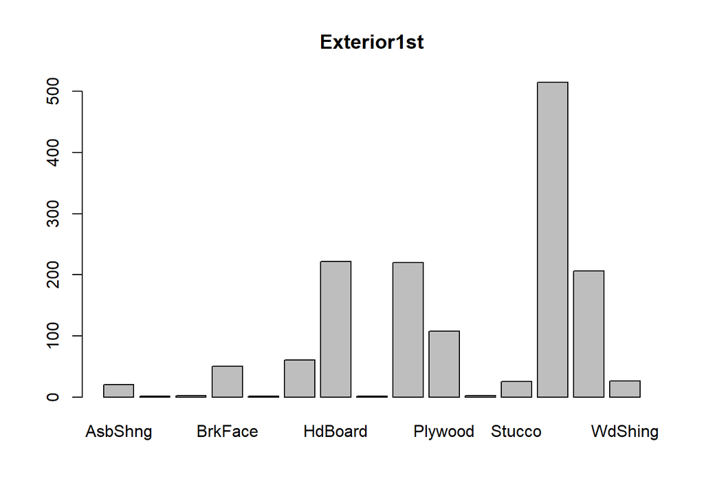

```r
barplot(t16,  main = "Exterior1st")
```

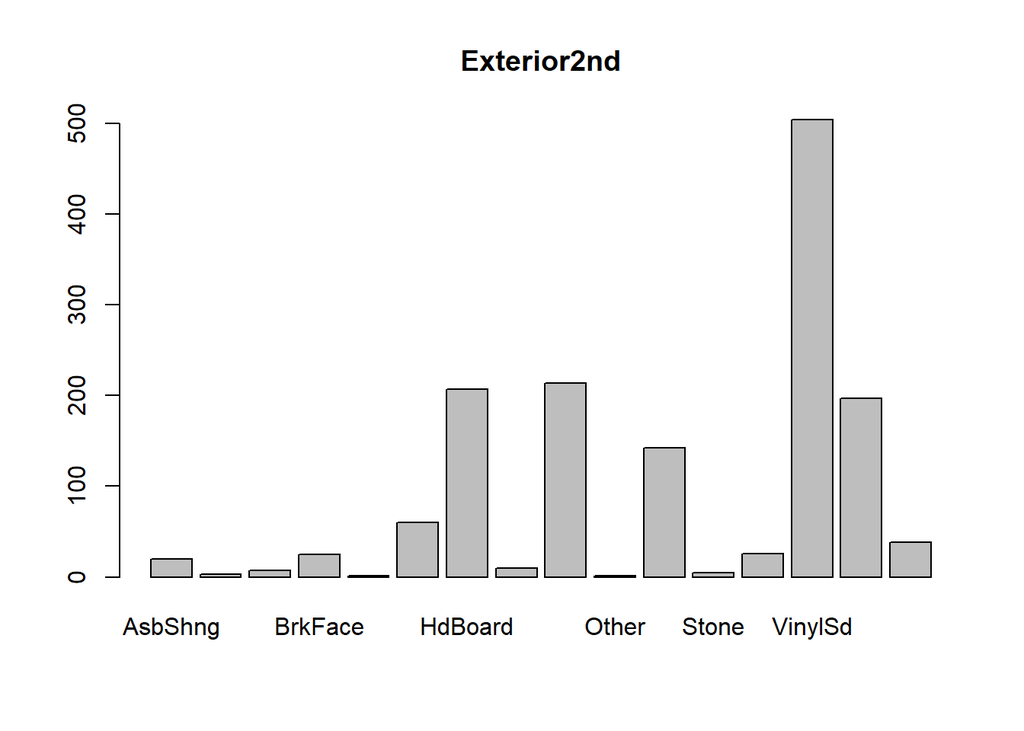

```r
barplot(t17,  main = "Exterior2nd")
```

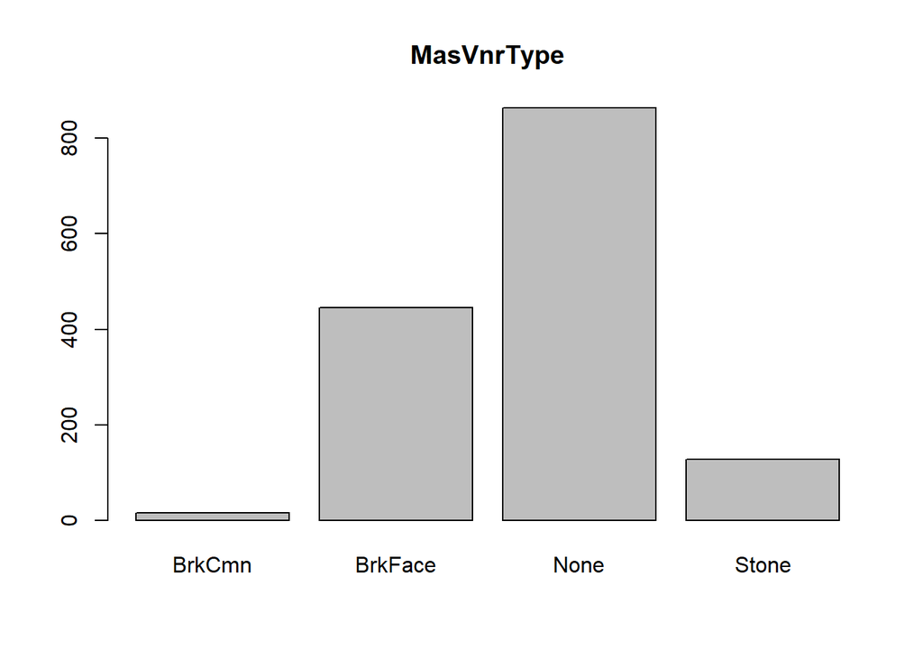

```r
barplot(t18,  main = "MasVnrType")
```

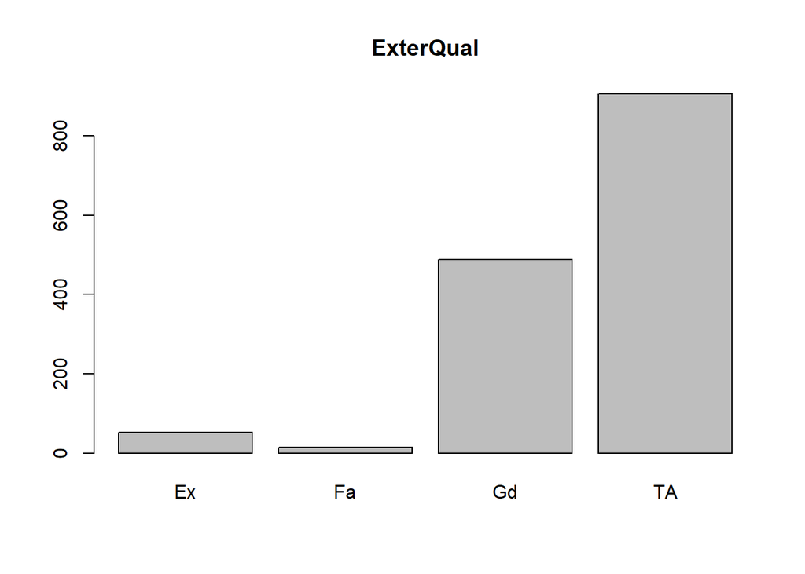

```r
barplot(t19,  main = "ExterQual")
```

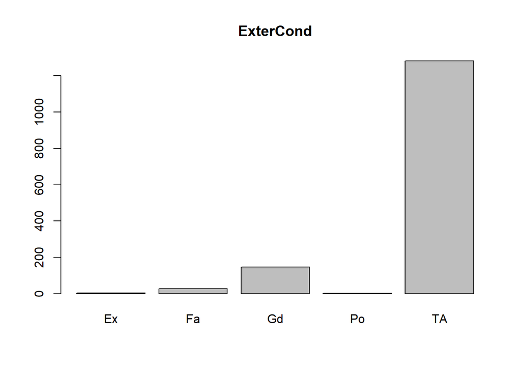

```r
barplot(t20,  main = "ExterCond")
```

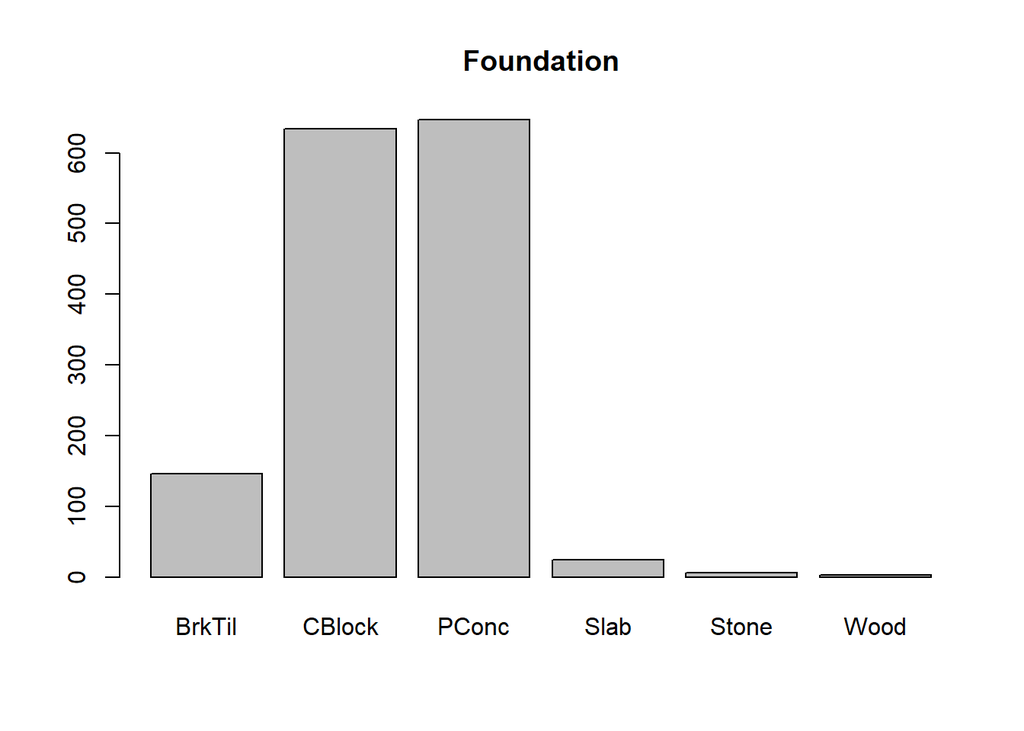

```r
barplot(t21,  main = "Foundation")
```

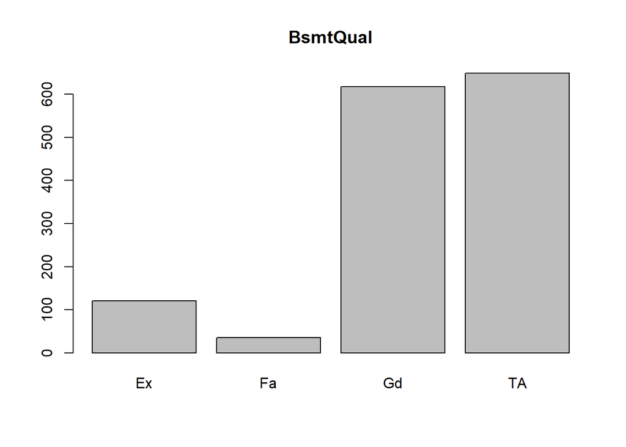

```r
barplot(t22,  main = "BsmtQual")
```

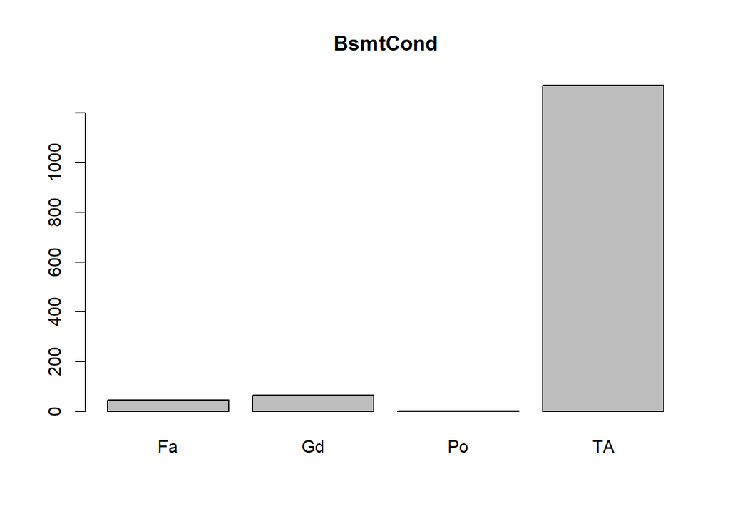

```r
barplot(t23,  main = "BsmtCond")
```

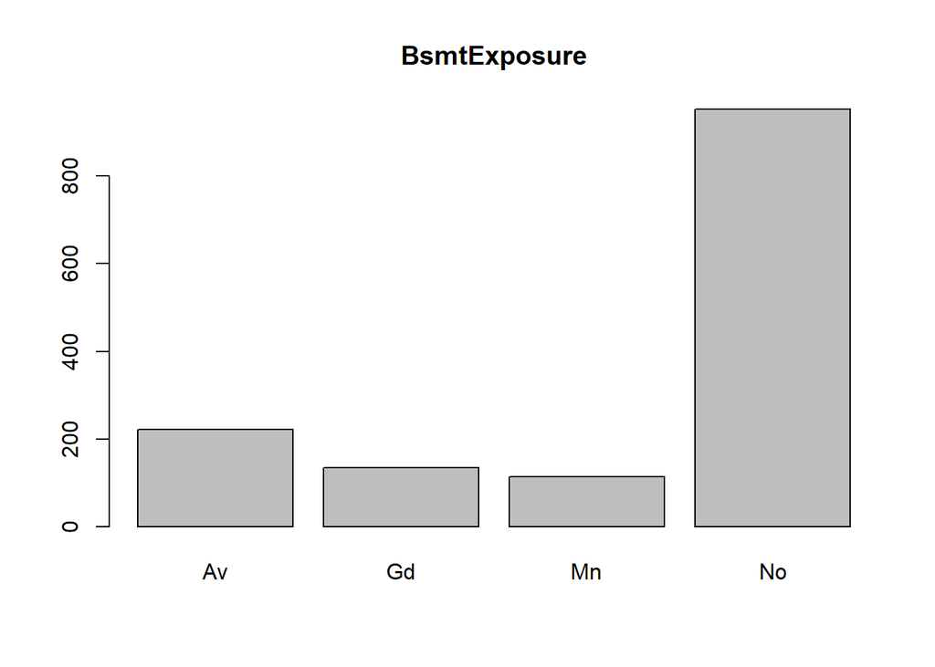

```r
barplot(t24,  main = "BsmtExposure")
```

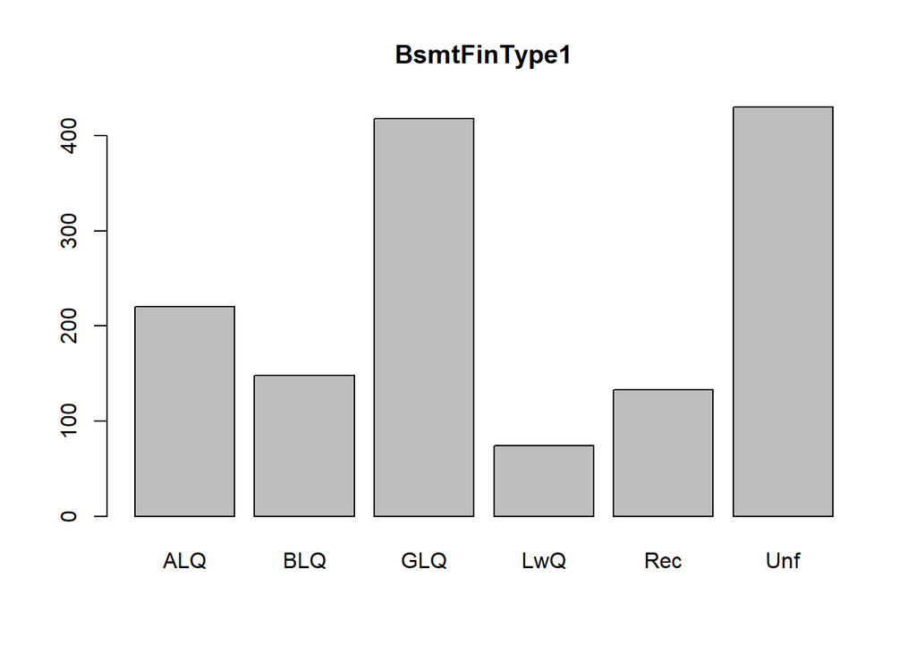

```r
barplot(t25,  main = "BsmtFinType1")
```

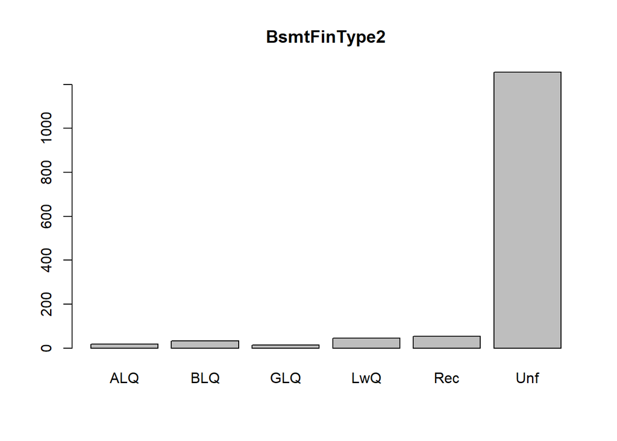

```r
barplot(t26,  main = "BsmtFinType2")
```

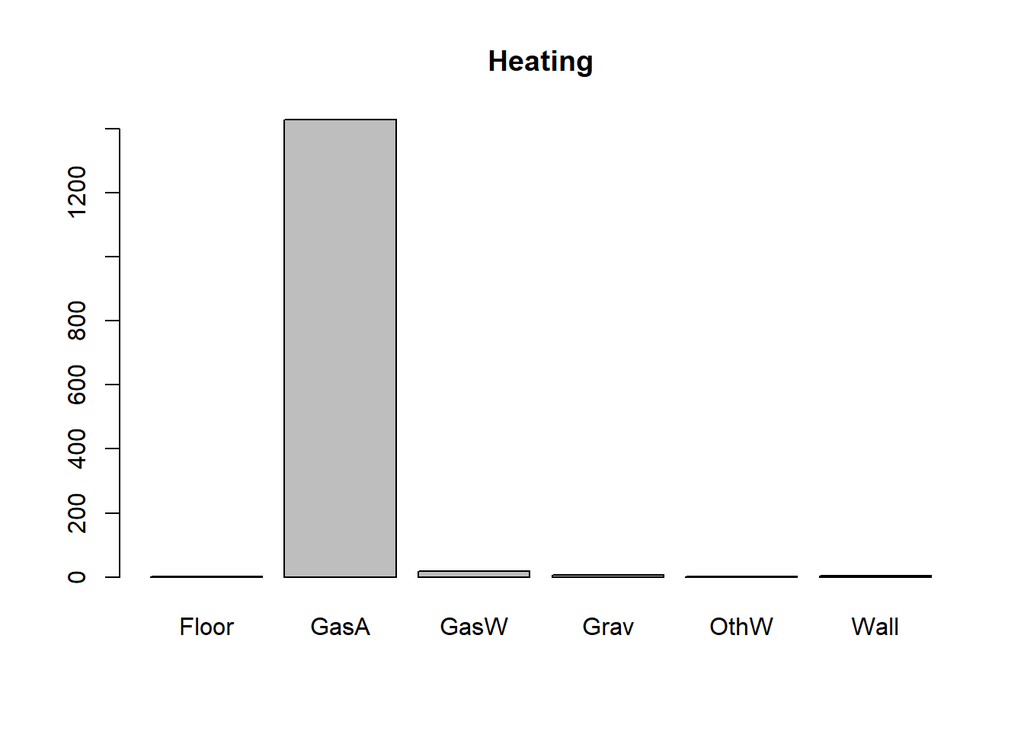

```r
barplot(t27,  main = "Heating")
```

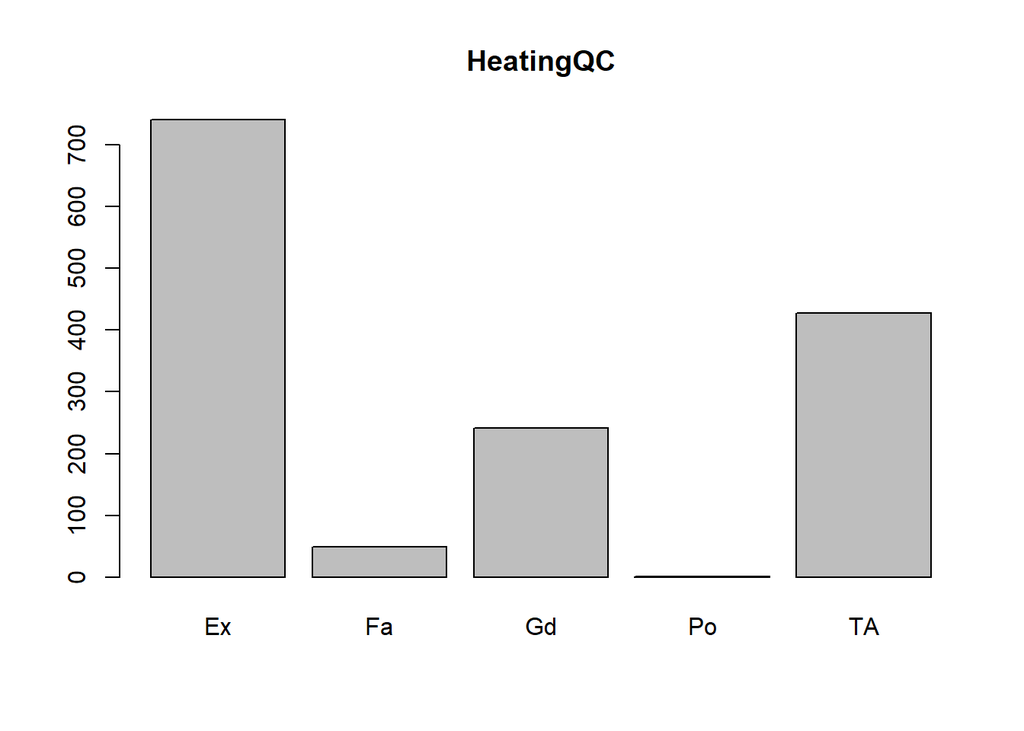

```r
barplot(t28,  main = "HeatingQC")
```

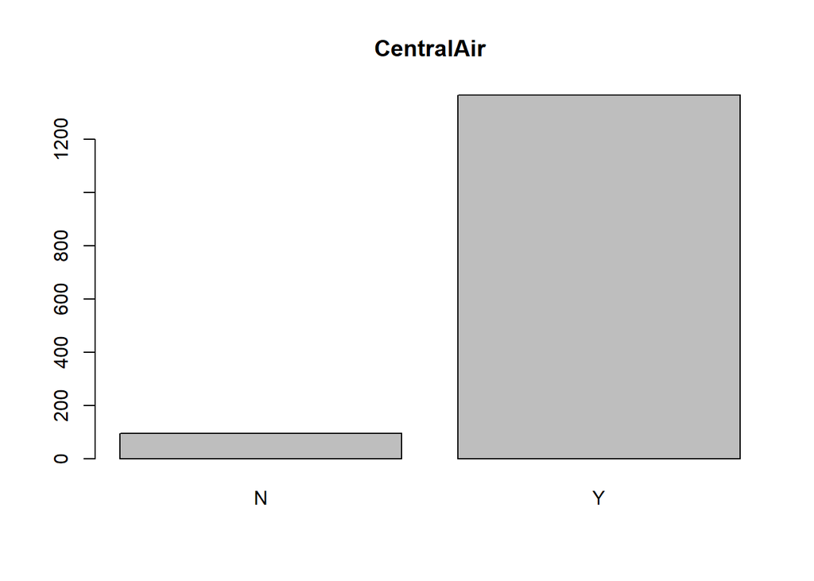

```r
barplot(t29,  main = "CentralAir")
```

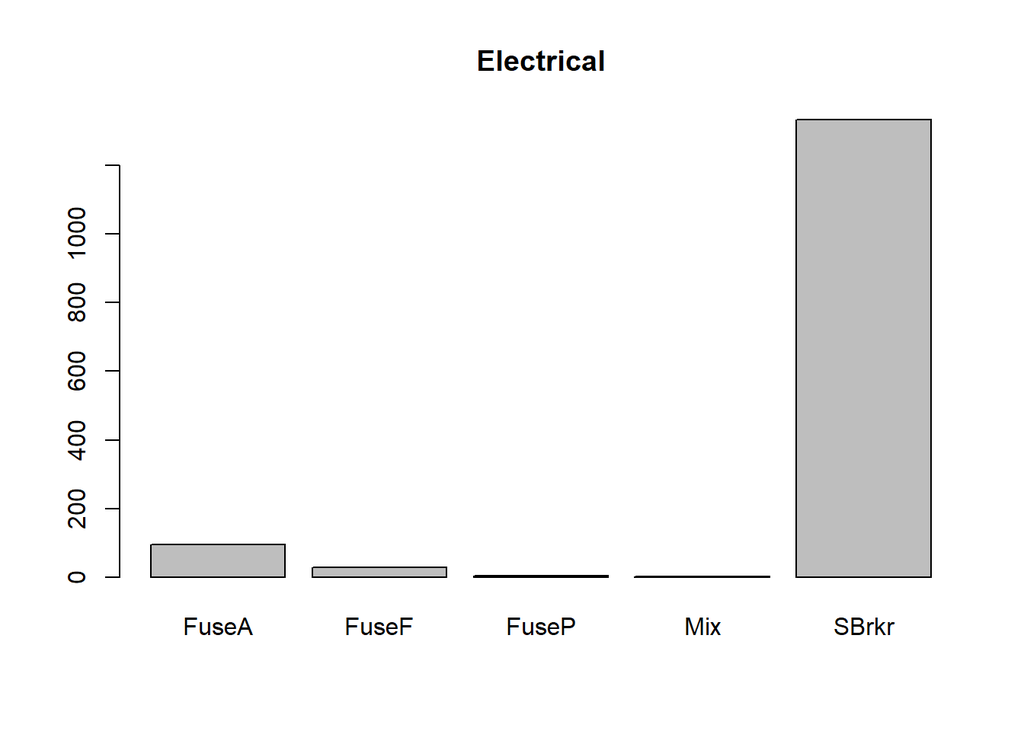

```r
barplot(t30,  main = "Electrical")
```

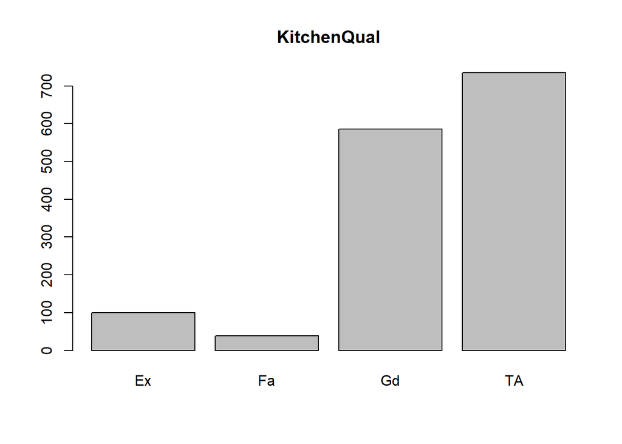

```r
barplot(t31,  main = "KitchenQual")
```

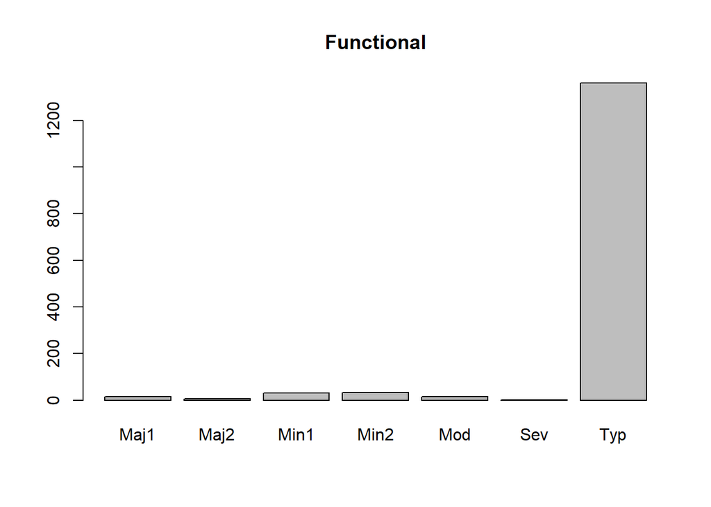

```r
barplot(t32,  main = "Functional")
```

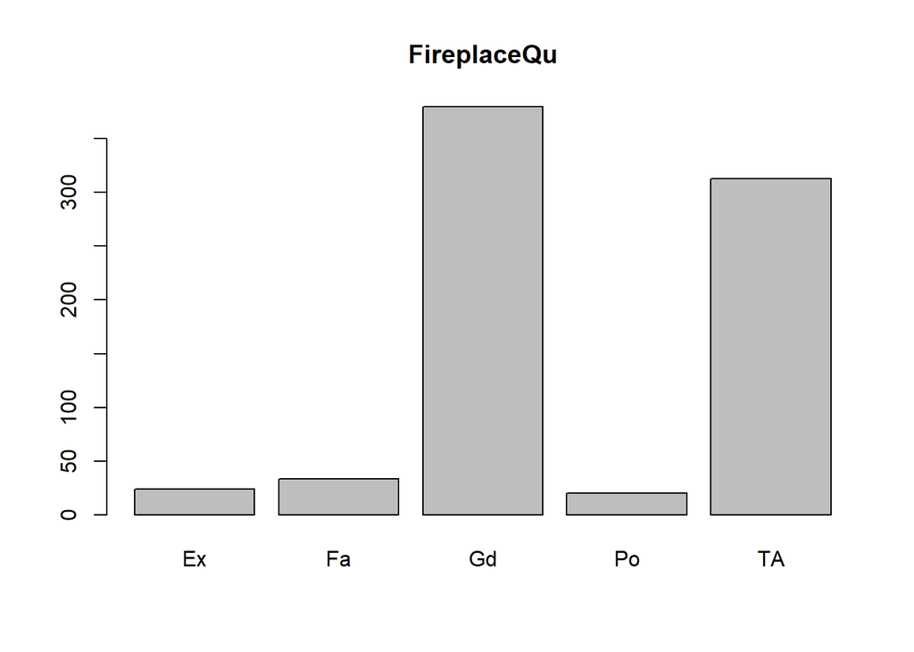

```r
barplot(t33,  main = "FireplaceQu")
```

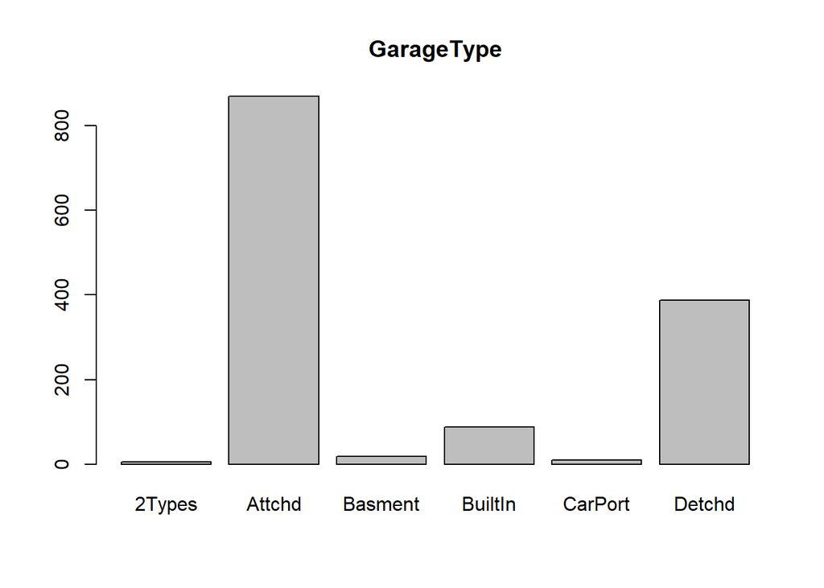

```r
barplot(t34,  main = "GarageType")
```

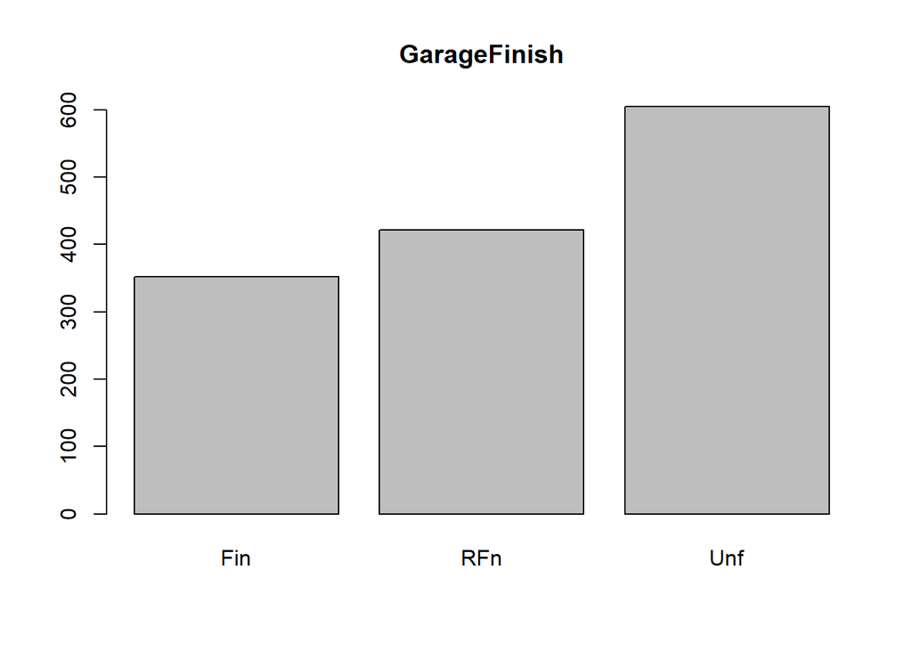

```r
barplot(t35,  main = "GarageFinish")
```

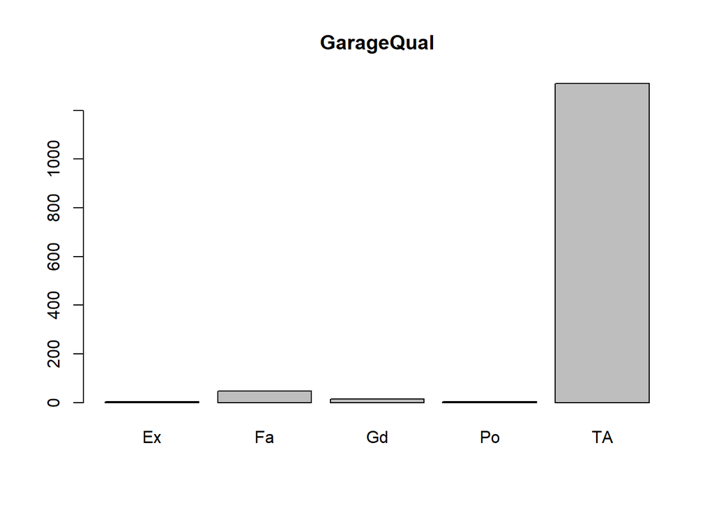

```r
barplot(t36,  main = "GarageQual")
```

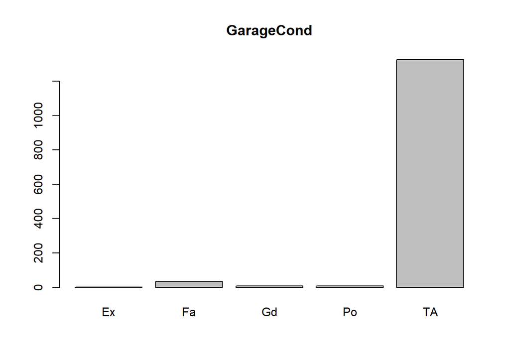

```r
barplot(t37,  main = "GarageCond")
```

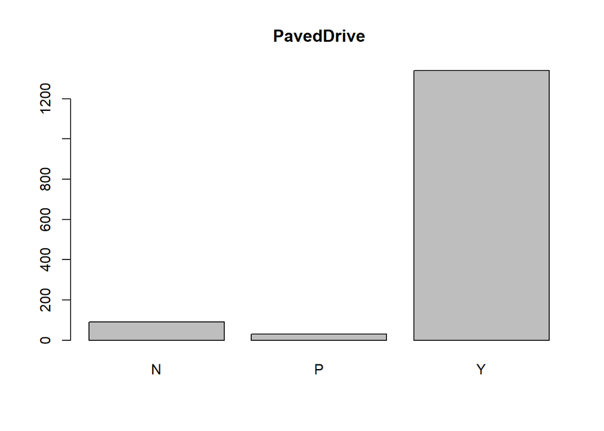

```r
barplot(t38,  main = "PavedDrive")
```

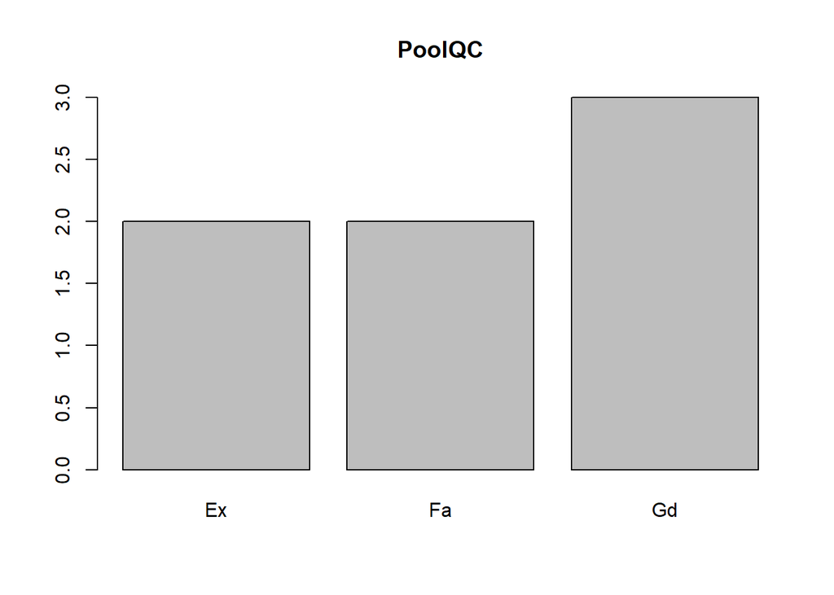

```r
barplot(t39,  main = "PoolQC")
```

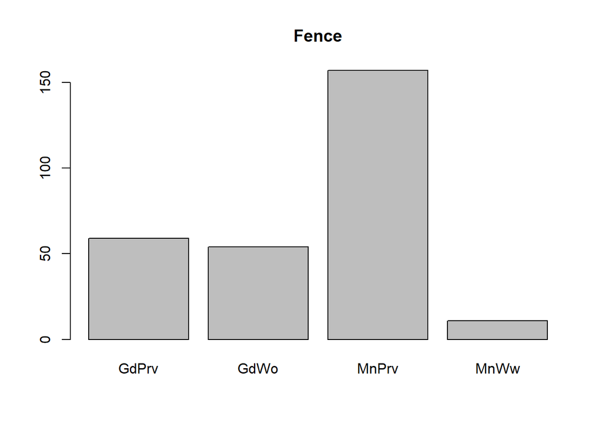

```r
barplot(t40,  main = "Fence")
```

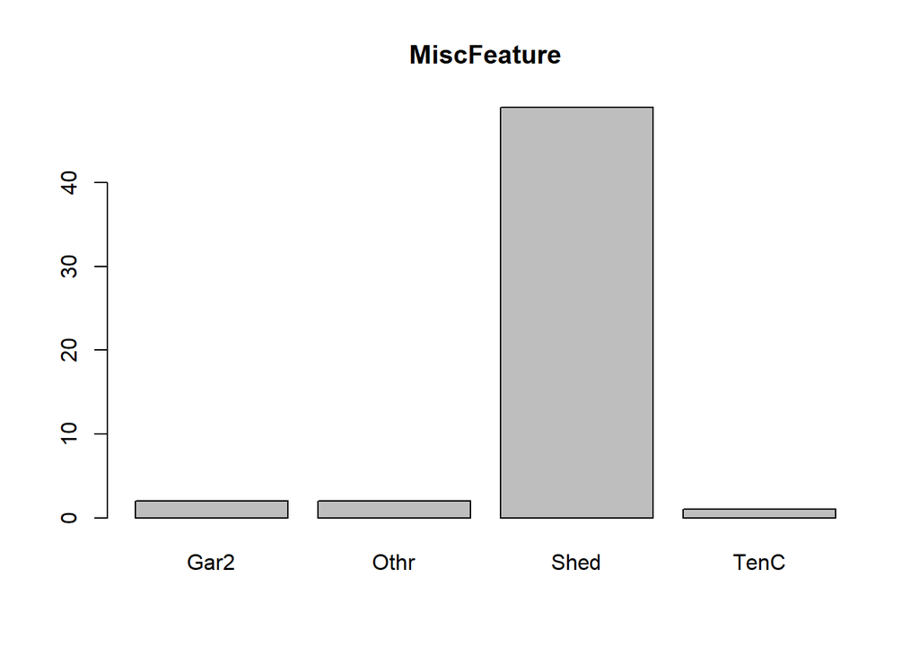

```r
barplot(t41,  main = "MiscFeature")
```

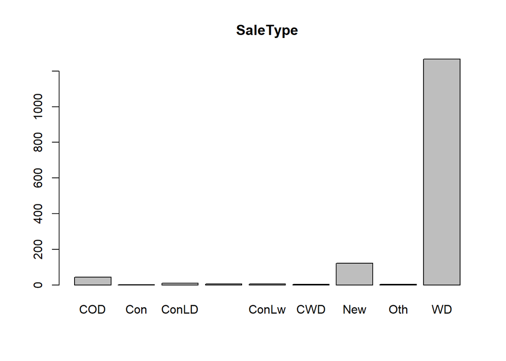

```r
barplot(t42,  main = "SaleType")
```

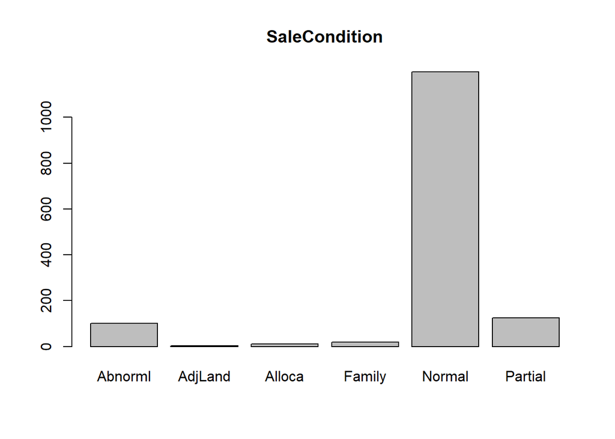

```r
barplot(t43,  main = "SaleCondition")
```

## Correlación de las variables numéricas

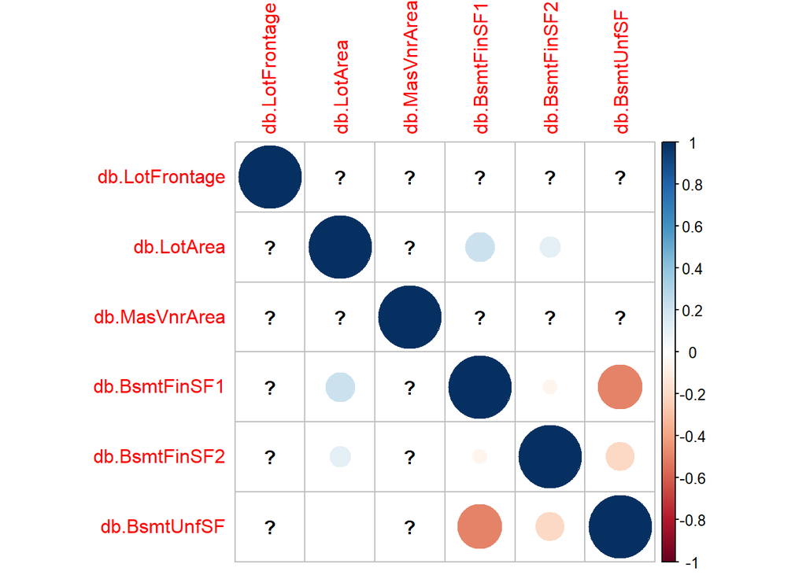

```r
corrplot::corrplot(cor(df1))
```

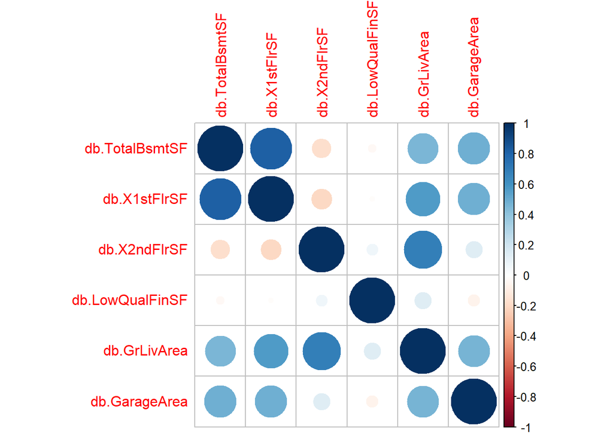

```r
corrplot::corrplot(cor(df2))
```

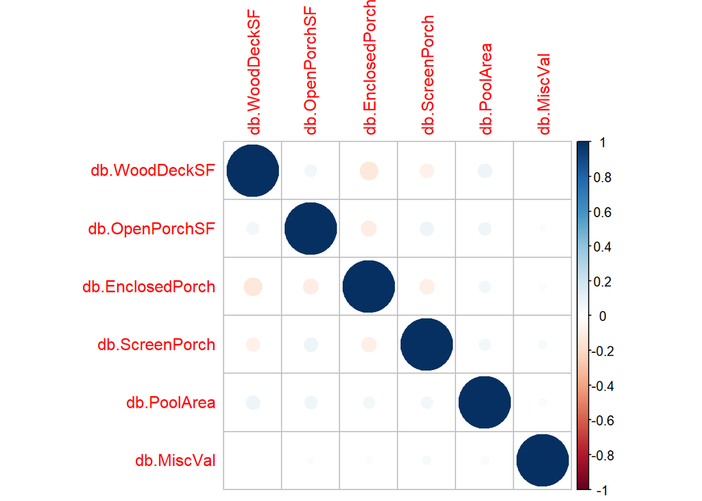

```r
corrplot::corrplot(cor(df3))
```

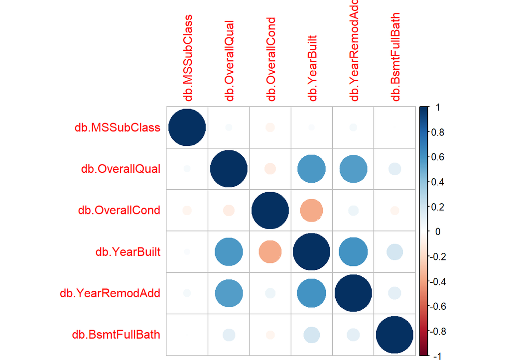

```r
corrplot::corrplot(cor(df4))
```

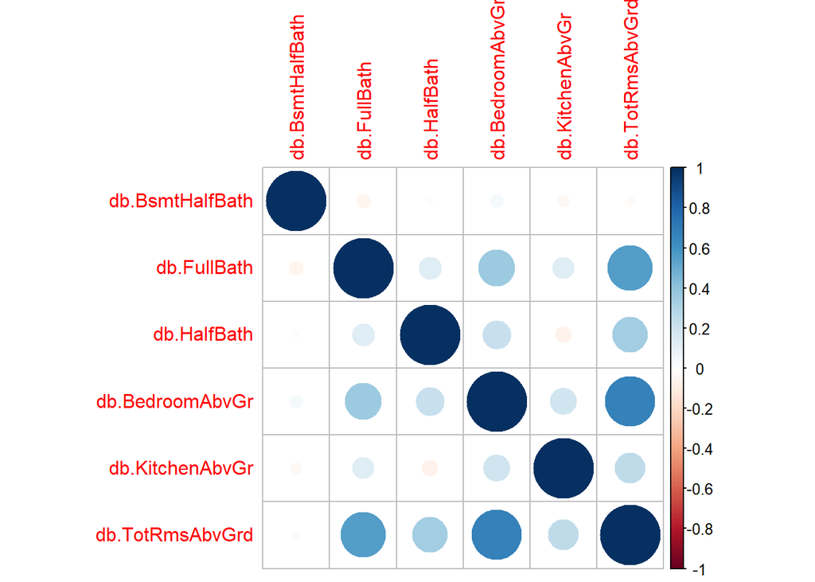

```r
corrplot::corrplot(cor(df5))
```

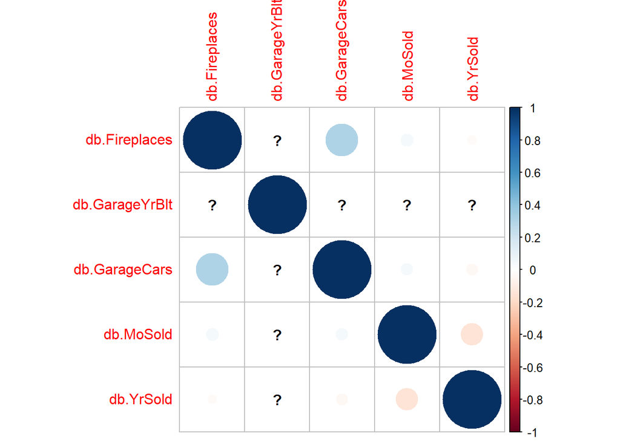

```r
corrplot::corrplot(cor(df6))
```

## Tabla de frecuencia de variables categóricas

```r
t1
```

```
##
## C (all)      FV      RH      RL      RM
##      10      65      16    1151     218
```

```r
t2
```

```
##
## Grvl Pave
##    6 1454
```

```r
t3
```

```
##
## Grvl Pave
##   50   41
```

```r
t4
```

```
##
## IR1 IR2 IR3 Reg
## 484  41  10 925
```

```r
t5
```

```
##
##  Bnk  HLS  Low  Lvl
##   63   50   36 1311
```

```r
t6
```

```
##
## AllPub NoSeWa
##   1459      1
```

```r
t7
```

```
##
##  Corner CulDSac     FR2     FR3  Inside
##     263      94      47       4    1052
```

```r
t8
```

```
##
##  Gtl  Mod  Sev
## 1382   65   13
```

```r
t9
```

```
##
## Blmngtn Blueste  BrDale BrkSide ClearCr CollgCr Crawfor Edwards Gilbert  IDOTRR
##      17       2      16      58      28     150      51     100      79      37
## MeadowV Mitchel   NAmes NoRidge NPkVill NridgHt  NWAmes OldTown  Sawyer SawyerW
##      17      49     225      41       9      77      73     113      74      59
## Somerst StoneBr   SWISU  Timber Veenker
##      86      25      25      38      11
```

```r
t10
```

```
##
## Artery  Feedr   Norm   PosA   PosN   RRAe   RRAn   RRNe   RRNn
##     48     81   1260      8     19     11     26      2      5
```

```r
t11
```

```
##
## Artery  Feedr   Norm   PosA   PosN   RRAe   RRAn   RRNn
##      2      6   1445      1      2      1      1      2
```

```r
t12
```

```
##
##   1Fam 2fmCon Duplex  Twnhs TwnhsE
##   1220     31     52     43    114
```

```r
t13
```

```
##
## 1.5Fin 1.5Unf 1Story 2.5Fin 2.5Unf 2Story SFoyer   SLvl
##    154     14    726      8     11    445     37     65
```

```r
t14
```

```
##
##    Flat   Gable Gambrel     Hip Mansard    Shed
##      13    1141      11     286       7       2
```

```r
t15
```

```
##
## ClyTile CompShg Membran   Metal    Roll Tar&Grv WdShake WdShngl
##       1    1434       1       1       1      11       5       6
```

```r
t16
```

```
##
## AsbShng AsphShn BrkComm BrkFace  CBlock CemntBd HdBoard ImStucc MetalSd Plywood
##      20       1       2      50       1      61     222       1     220     108
##   Stone  Stucco VinylSd Wd Sdng WdShing
##       2      25     515     206      26
```

```r
t17
```

```
##
## AsbShng AsphShn Brk Cmn BrkFace  CBlock CmentBd HdBoard ImStucc MetalSd   Other
##      20       3       7      25       1      60     207      10     214       1
## Plywood   Stone  Stucco VinylSd Wd Sdng Wd Shng
##     142       5      26     504     197      38
```

```r
t18
```

```
##
##  BrkCmn BrkFace    None   Stone
##      15     445     864     128
```

```r
t19
```

```
##
##  Ex  Fa  Gd  TA
##  52  14 488 906
```

```r
t20
```

```
##
##   Ex   Fa   Gd   Po   TA
##    3   28  146    1 1282
```

```r
t21
```

```
##
## BrkTil CBlock  PConc   Slab  Stone   Wood
##    146    634    647     24      6      3
```

```r
t22
```

```
##
##  Ex  Fa  Gd  TA
## 121  35 618 649
```

```r
t23
```

```
##
##   Fa   Gd   Po   TA
##   45   65    2 1311
```

```r
t24
```

```
##
##  Av  Gd  Mn  No
## 221 134 114 953
```

```r
t25
```

```
##
## ALQ BLQ GLQ LwQ Rec Unf
## 220 148 418  74 133 430
```

```r
t26
```

```
##
##  ALQ  BLQ  GLQ  LwQ  Rec  Unf
##   19   33   14   46   54 1256
```

```r
t27
```

```
##
## Floor  GasA  GasW  Grav  OthW  Wall
##     1  1428    18     7     2     4
```

```r
t28
```

```
##
##  Ex  Fa  Gd  Po  TA
## 741  49 241   1 428
```

```r
t29
```

```
##
##    N    Y
##   95 1365
```

```r
t30
```

```
##
## FuseA FuseF FuseP   Mix SBrkr
##    94    27     3     1  1334
```

```r
t31
```

```
##
##  Ex  Fa  Gd  TA
## 100  39 586 735
```

```r
t32
```

```
##
## Maj1 Maj2 Min1 Min2  Mod  Sev  Typ
##   14    5   31   34   15    1 1360
```

```r
t33
```

```
##
##  Ex  Fa  Gd  Po  TA
##  24  33 380  20 313
```

```r
t34
```

```
##
##  2Types  Attchd Basment BuiltIn CarPort  Detchd
##       6     870      19      88       9     387
```

```r
t35
```

```
##
## Fin RFn Unf
## 352 422 605
```

```r
t36
```

```
##
##   Ex   Fa   Gd   Po   TA
##    3   48   14    3 1311
```

```r
t37
```

```
##
##   Ex   Fa   Gd   Po   TA
##    2   35    9    7 1326
```

```r
t38
```

```
##
##    N    P    Y
##   90   30 1340
```

```r
t39
```

```
##
## Ex Fa Gd
##  2  2  3
```

```r
t40
```

```
##
## GdPrv  GdWo MnPrv  MnWw
##    59    54   157    11
```

```r
t41
```

```
##
## Gar2 Othr Shed TenC
##    2    2   49    1
```

```r
t42
```

```
##
##   COD   Con ConLD ConLI ConLw   CWD   New   Oth    WD
##    43     2     9     5     5     4   122     3  1267
```

```r
t43
```

```
##
## Abnorml AdjLand  Alloca  Family  Normal Partial
##     101       4      12      20    1198     125
```

```r
library(arules)
library(psych)
library(FactoMineR)
library(fpc)
library(factoextra)
```

```r
library(corrplot)
db<-read.csv('train.csv')

#Quitar nulos
db[is.na(db)] <- 0
#Calculo de percentiles
percentil <- quantile(db$SalePrice)
#Percentiles
estado<-c('Estado')
db$Estado<-estado
#Economica=0
#Intermedia=1
#Cara=2
db <- within(db, Estado[SalePrice<=129975] <- 'Economica')
db$Estado[(db$SalePrice>129975 & db$SalePrice<=163000)] <- 'Intermedia'
db$Estado[db$SalePrice>163000] <- 'Cara'


#Cambio de tipo de columnas a numerico, ya que necesitamos las variables numericas

db$SalePrice<-as.numeric(db$SalePrice)
db$GrLivArea<-as.numeric(db$GrLivArea)

db$LotFrontage<-as.numeric(db$LotFrontage)
db$LotArea<-as.numeric(db$LotArea)
db$YearBuilt<-as.numeric(db$YearBuilt)
db$YearRemodAdd<-as.numeric(db$YearRemodAdd)
db$MasVnrArea<-as.numeric(db$MasVnrArea)
db$BsmtFinSF1<-as.numeric(db$BsmtFinSF1)
db$BsmtFinSF2<-as.numeric(db$BsmtFinSF2)
db$BsmtUnfSF<-as.numeric(db$BsmtUnfSF)
db$TotalBsmtSF<-as.numeric(db$TotalBsmtSF)
db$X1stFlrSF<-as.numeric(db$X1stFlrSF)
db$X2ndFlrSF<-as.numeric(db$X2ndFlrSF)
db$LowQualFinSF<-as.numeric(db$LowQualFinSF)

db$GarageArea<-as.numeric(db$GarageArea)
db$WoodDeckSF<-as.numeric(db$WoodDeckSF)
db$OpenPorchSF<-as.numeric(db$OpenPorchSF)
db$ScreenPorch<-as.numeric(db$ScreenPorch)
db$EnclosedPorch<-as.numeric(db$EnclosedPorch)
db$PoolArea<-as.numeric(db$PoolArea)
db$MiscVal<-as.numeric(db$MiscVal)


#La variable predictora como factor
db$Estado<-as.factor(db$Estado)

#Experimento repetiblee
set.seed(123)
datos<-data.frame(db$Estado,db$SalePrice,db$GrLivArea,db$LotFrontage,db$LotArea,db$YearBuilt,db$YearRemodAdd,db$MasVnrArea,db$BsmtFinSF1,db$BsmtFinSF2,db$BsmtUnfSF,db$TotalBsmtSF,db$X1stFlrSF,db$X2ndFlrSF,db$LowQualFinSF,db$GarageArea,db$WoodDeckSF,db$OpenPorchSF,db$ScreenPorch,db$EnclosedPorch,db$PoolArea,db$MiscVal)
#
rcor<-cor(datos[,2:22],use = "pairwise.complete.obs")
deter<-det(rcor)#Si el determinante de la matriz de correlación es cercano a 0 significa que hay multicolinealidad
```

La variable SalePrice es cuantitativa continua y representa el precio de cada casa a la venta, es decir, cada casa del dataset analizado. Cabe mencionar que esta variable fue utilizada para clasificar las casas entre “Economica”, “Intermedia” o “Cara”, es decir, se creó una nueva variable para el dataset. A continuación se presenta de forma gráfica la variabe descrita.

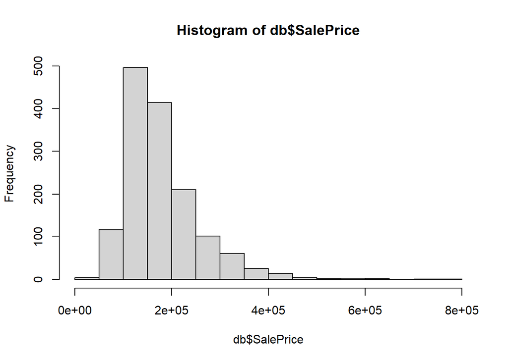

```r
hist(x = db$SalePrice)
```

## Verificar el determinante de la matriz de correlación es cercano a 0 significa que hay multicolinealidad

```r
deter
```

```
## [1] 1.057912e-34
```

Como se observa el determinantee de la matriz de correlacion es cercano a 0, por ende, significa que existe multicolinealidad. Sin embargo tambien debemos de ver el nivel de significacion de la prueba de Barlett donde la hipotesis nula es, la matriz de correlaciones es igual a la matriz de identidad, en este caso buscamos rechazar la hipotesis nula.

```r
cortest.bartlett(datos[,-1])
```

```
## R was not square, finding R from data
```

```
## $chisq
## [1] 113527.1
##
## $p.value
## [1] 0
##
## $df
## [1] 210
```

Se observa que el valor de P es de 0, siendo menor a 0.05, indicando que el analisis factorial puede funcionar. Ademas, podemos mostrar la matriz de correlacion para fines de aprendizaje.

```r
#se muestra la matriz de correlación
cor(datos[,-1],use = "pairwise.complete.obs")
```

```
##                  db.SalePrice db.GrLivArea db.LotFrontage  db.LotArea
## db.SalePrice       1.00000000  0.708624478    0.209623945  0.26384335
## db.GrLivArea       0.70862448  1.000000000    0.220347232  0.26311617
## db.LotFrontage     0.20962394  0.220347232    1.000000000  0.10073881
## db.LotArea         0.26384335  0.263116167    0.100738810  1.00000000
## db.YearBuilt       0.52289733  0.199009714    0.036853429  0.01422765
## db.YearRemodAdd    0.50710097  0.287388520    0.078685515  0.01378843
## db.MasVnrArea      0.47261450  0.388052052    0.105009833  0.10332051
## db.BsmtFinSF1      0.38641981  0.208171130    0.076669997  0.21410313
## db.BsmtFinSF2     -0.01137812 -0.009639892   -0.009312309  0.11116975
## db.BsmtUnfSF       0.21447911  0.240257268    0.160829277 -0.00261836
## db.TotalBsmtSF     0.61358055  0.454868203    0.238273669  0.26083313
## db.X1stFlrSF       0.60585218  0.566023969    0.245180931  0.29947458
## db.X2ndFlrSF       0.31933380  0.687501064    0.042549244  0.05098595
## db.LowQualFinSF   -0.02560613  0.134682813    0.049981430  0.00477897
## db.GarageArea      0.62343144  0.468997477    0.201473353  0.18040276
## db.WoodDeckSF      0.32441344  0.247432821   -0.016779759  0.17169769
## db.OpenPorchSF     0.31585623  0.330223962    0.069604952  0.08477381
## db.ScreenPorch     0.11144657  0.101510396    0.022968732  0.04316038
## db.EnclosedPorch  -0.12857796  0.009113210    0.027366105 -0.01833973
## db.PoolArea        0.09240355  0.170205336    0.114106359  0.07767239
## db.MiscVal        -0.02118958 -0.002415640   -0.059605730  0.03806769
##                  db.YearBuilt db.YearRemodAdd db.MasVnrArea db.BsmtFinSF1
## db.SalePrice      0.522897333     0.507100967    0.47261450   0.386419806
## db.GrLivArea      0.199009714     0.287388520    0.38805205   0.208171130
## db.LotFrontage    0.036853429     0.078685515    0.10500983   0.076669997
## db.LotArea        0.014227652     0.013788427    0.10332051   0.214103131
## db.YearBuilt      1.000000000     0.592854976    0.31160011   0.249503197
## db.YearRemodAdd   0.592854976     1.000000000    0.17652918   0.128450547
## db.MasVnrArea     0.311600107     0.176529181    1.00000000   0.261256055
## db.BsmtFinSF1     0.249503197     0.128450547    0.26125605   1.000000000
## db.BsmtFinSF2    -0.049106831    -0.067758514   -0.07132963  -0.050117400
## db.BsmtUnfSF      0.149040392     0.181133087    0.11386216  -0.495251469
## db.TotalBsmtSF    0.391452002     0.291065583    0.36006737   0.522396052
## db.X1stFlrSF      0.281985859     0.240379268    0.33985041   0.445862656
## db.X2ndFlrSF      0.010307660     0.140023779    0.17380000  -0.137078986
## db.LowQualFinSF  -0.183784344    -0.062419100   -0.06862798  -0.064502597
## db.GarageArea     0.478953820     0.371599809    0.37088415   0.296970385
## db.WoodDeckSF     0.224880142     0.205725920    0.15999053   0.204306145
## db.OpenPorchSF    0.188685840     0.226297633    0.12252833   0.111760613
```

[output cut: 77 more lines]

```
## db.MasVnrArea    -0.029512249
## db.BsmtFinSF1     0.003571473
## db.BsmtFinSF2     0.004939781
## db.BsmtUnfSF     -0.023836645
## db.TotalBsmtSF   -0.018478922
## db.X1stFlrSF     -0.021095719
## db.X2ndFlrSF      0.016196875
## db.LowQualFinSF  -0.003792871
## db.GarageArea    -0.027399914
## db.WoodDeckSF    -0.009551228
## db.OpenPorchSF   -0.018583739
## db.ScreenPorch    0.031945761
## db.EnclosedPorch  0.018360600
## db.PoolArea       0.029668651
## db.MiscVal        1.000000000
```

```r
#Esta función normaliza los datos de una vez
compPrinc<-prcomp(datos[,2:22], scale = T)



summary(compPrinc)
```

```
## Importance of components:
##                           PC1     PC2     PC3     PC4     PC5     PC6     PC7
## Standard deviation     2.2405 1.35693 1.30688 1.23596 1.05165 1.03500 1.00958
## Proportion of Variance 0.2391 0.08768 0.08133 0.07274 0.05266 0.05101 0.04854
## Cumulative Proportion  0.2391 0.32673 0.40806 0.48080 0.53347 0.58448 0.63301
##                            PC8     PC9   PC10   PC11    PC12    PC13    PC14
## Standard deviation     0.99713 0.96529 0.9347 0.9199 0.91606 0.84303 0.82724
## Proportion of Variance 0.04735 0.04437 0.0416 0.0403 0.03996 0.03384 0.03259
## Cumulative Proportion  0.68036 0.72473 0.7663 0.8066 0.84659 0.88043 0.91302
##                           PC15    PC16    PC17    PC18    PC19      PC20
## Standard deviation     0.74666 0.71980 0.57073 0.47449 0.44731 1.562e-15
## Proportion of Variance 0.02655 0.02467 0.01551 0.01072 0.00953 0.000e+00
## Cumulative Proportion  0.93957 0.96424 0.97975 0.99047 1.00000 1.000e+00
##                             PC21
## Standard deviation     9.759e-16
## Proportion of Variance 0.000e+00
## Cumulative Proportion  1.000e+00
```

```r
compPrincPCA<-PCA(datos[,-1],ncp=ncol(datos[,-1]), scale.unit = T)
```

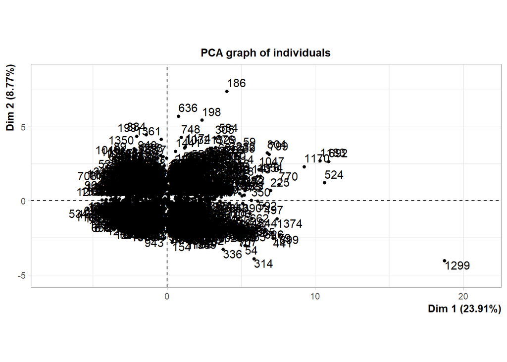

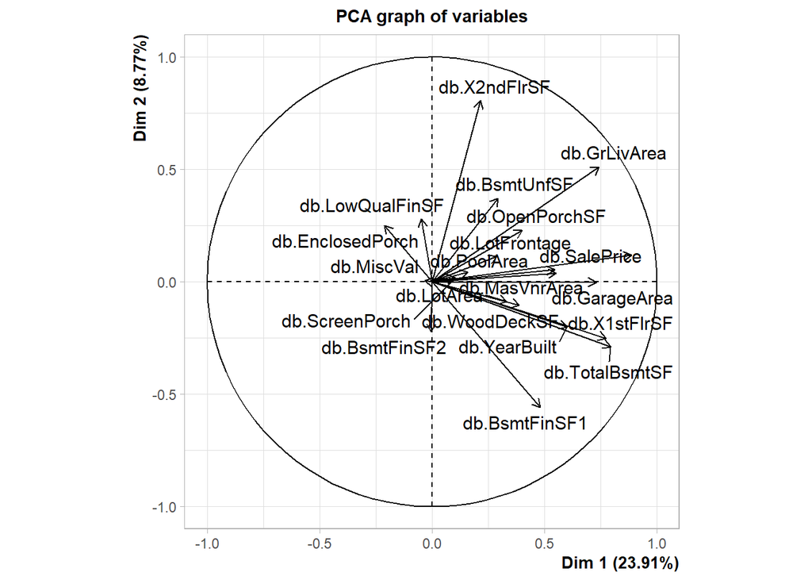

```r
summary(compPrincPCA)
```

```
##
## Call:
## PCA(X = datos[, -1], scale.unit = T, ncp = ncol(datos[, -1]))
##
##
## Eigenvalues
##                        Dim.1   Dim.2   Dim.3   Dim.4   Dim.5   Dim.6   Dim.7
## Variance               5.020   1.841   1.708   1.528   1.106   1.071   1.019
## % of var.             23.905   8.768   8.133   7.274   5.266   5.101   4.854
## Cumulative % of var.  23.905  32.673  40.806  48.080  53.347  58.448  63.301
##                        Dim.8   Dim.9  Dim.10  Dim.11  Dim.12  Dim.13  Dim.14
## Variance               0.994   0.932   0.874   0.846   0.839   0.711   0.684
## % of var.              4.735   4.437   4.160   4.030   3.996   3.384   3.259
## Cumulative % of var.  68.036  72.473  76.633  80.663  84.659  88.043  91.302
##                       Dim.15  Dim.16  Dim.17  Dim.18  Dim.19  Dim.20  Dim.21
## Variance               0.557   0.518   0.326   0.225   0.200   0.000   0.000
## % of var.              2.655   2.467   1.551   1.072   0.953   0.000   0.000
## Cumulative % of var.  93.957  96.424  97.975  99.047 100.000 100.000 100.000
##
## Individuals (the 10 first)
##                      Dist    Dim.1    ctr   cos2    Dim.2    ctr   cos2
## 1                |  2.636 |  0.597  0.005  0.051 |  0.577  0.012  0.048 |
## 2                |  2.711 |  0.212  0.001  0.006 | -1.747  0.114  0.415 |
## 3                |  2.388 |  0.829  0.009  0.121 |  0.920  0.032  0.149 |
## 4                |  4.977 | -1.649  0.037  0.110 |  2.126  0.168  0.182 |
## 5                |  3.675 |  2.797  0.107  0.579 |  1.201  0.054  0.107 |
## 6                |  2.769 | -0.572  0.004  0.043 | -0.236  0.002  0.007 |
## 7                |  4.100 |  3.229  0.142  0.620 | -1.944  0.141  0.225 |
## 8                |  5.226 |  0.821  0.009  0.025 |  1.481  0.082  0.080 |
## 9                |  4.273 | -1.741  0.041  0.166 |  2.017  0.151  0.223 |
## 10               |  3.331 | -2.278  0.071  0.468 | -1.435  0.077  0.186 |
##                   Dim.3    ctr   cos2
## 1                -0.952  0.036  0.131 |
## 2                 0.271  0.003  0.010 |
## 3                -0.970  0.038  0.165 |
## 4                 2.085  0.174  0.175 |
## 5                -0.515  0.011  0.020 |
## 6                -0.351  0.005  0.016 |
## 7                -0.145  0.001  0.001 |
## 8                 1.471  0.087  0.079 |
```

[output cut: 11 more lines]

```
## db.MasVnrArea    |  0.552  6.073  0.305 |  0.038  0.079  0.001 | -0.053  0.166
## db.BsmtFinSF1    |  0.481  4.615  0.232 | -0.559 16.960  0.312 |  0.284  4.727
## db.BsmtFinSF2    | -0.004  0.000  0.000 | -0.223  2.699  0.050 |  0.344  6.928
## db.BsmtUnfSF     |  0.294  1.722  0.086 |  0.371  7.494  0.138 | -0.267  4.164
##                    cos2
## db.SalePrice      0.000 |
## db.GrLivArea      0.061 |
## db.LotFrontage    0.047 |
## db.LotArea        0.171 |
## db.YearBuilt      0.324 |
## db.YearRemodAdd   0.237 |
## db.MasVnrArea     0.003 |
## db.BsmtFinSF1     0.081 |
## db.BsmtFinSF2     0.118 |
## db.BsmtUnfSF      0.071 |
```

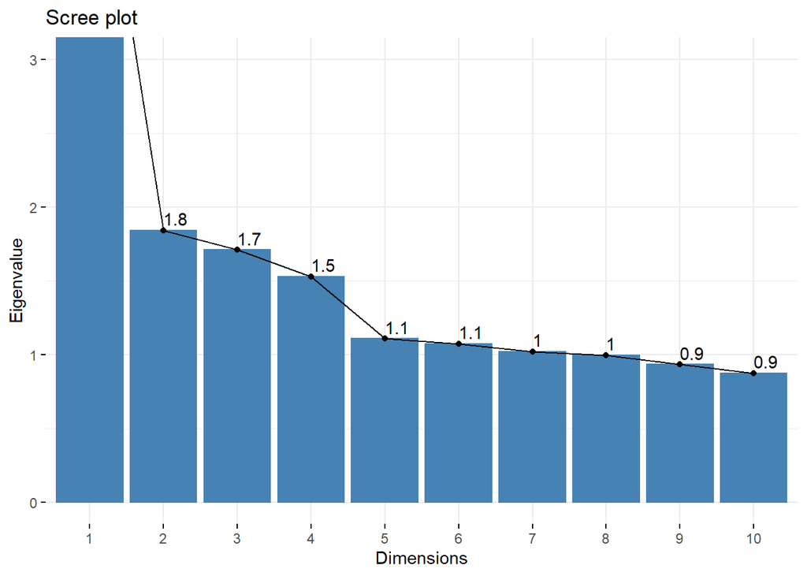

```r
#Se obtiene el scree plot de las componentes principales.

fviz_eig(compPrinc, addlabels = TRUE, choice = c("eigenvalue"), ylim = c(0, 3))
```

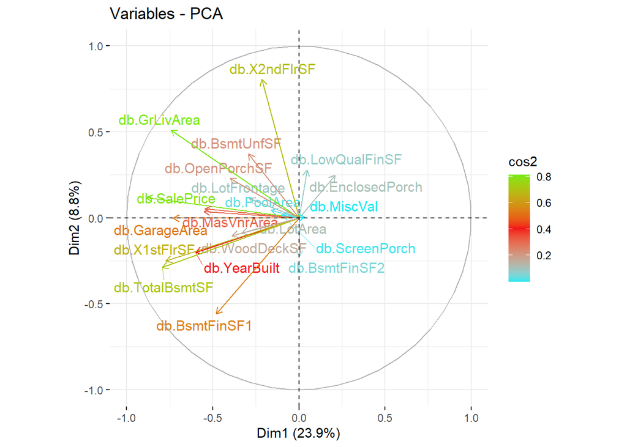

```r
fviz_pca_var(compPrinc, col.var = "cos2",
             gradient.cols = c("#0FE8F3", "#F30F19", "#79E915"),
             repel = TRUE # Avoid text overlapping
)
```

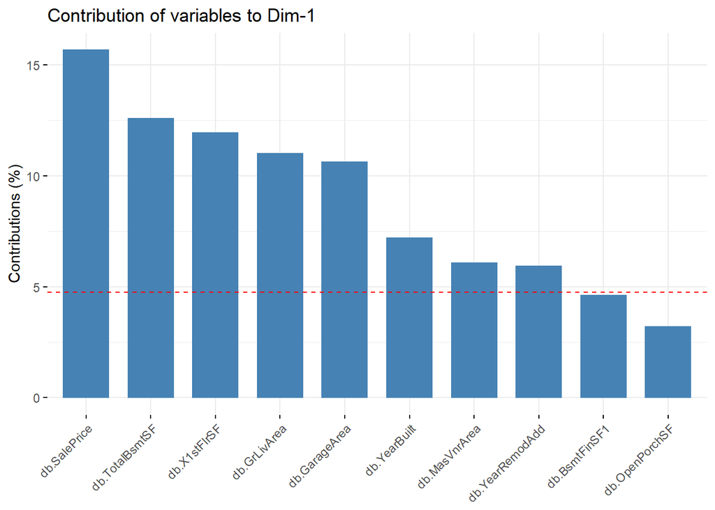

```r
fviz_contrib(compPrinc, choice = "var", axes = 1, top = 10) #Dimensión 1
```

Como podemos observar este primer componente lo podemos represantar como el tamano de la propiedad, ya que TotalBsmtSF es el tamano base que tiene el terreno, contando tambien que en este componente, vemos la variable de tamano de viviendo, area de jardin, y tamano del garage, entre otros.

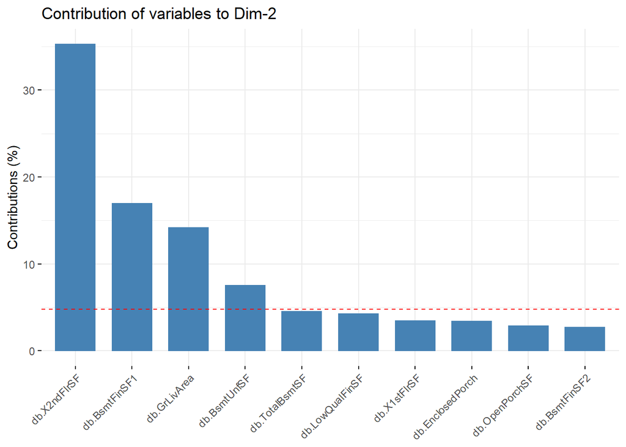

```r
fviz_contrib(compPrinc, choice = "var", axes = 2, top = 10) #Dimensión 2
```

Este componente lo podemos ver represantado en el tamano de la casa, sobre todo por la cantidad de niveles que posee.

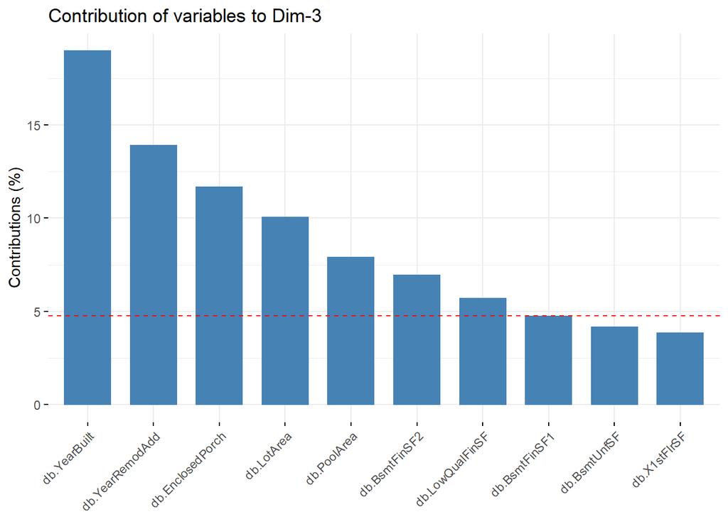

```r
fviz_contrib(compPrinc, choice = "var", axes = 3, top = 10) #Dimensión 3
```

Este componente lo podemos ver represantado como la longevidad de la casa, ya que abarca desde al ano de construccion hasta cuando fue remodelada, asi como si se ha concluido sus construcciones.